# Analisi delle Applicazioni Android in Google Play Store

### Corso di Data Mining 2018/2019

Joey Tribbiani

Chandler Bing

## Operazioni Preliminari

```python
# Python ≥3.5 is required
import sys
assert sys.version_info >= (3, 5)
# Scikit-Learn ≥0.20 is required
import sklearn
assert sklearn.__version__ >= "0.20"
# Common imports
import numpy as np
import os
#imports pandas
import pandas as ps
from IPython.display import Image
import os
#import warnings and Repress Warnings
import warnings
warnings.filterwarnings("ignore", message="numpy.dtype size changed")
warnings.filterwarnings("ignore", message="numpy.ufunc size changed")
warnings.filterwarnings("ignore", message="numpy.ndarray size changed")
warnings.filterwarnings('ignore')
# to make this notebook's output stable across runs
np.random.seed(42)
# To plot pretty figures
%matplotlib inline
import matplotlib as mpl
import matplotlib.pyplot as plt
import seaborn as sns
sns.set(style="whitegrid") #White Grid
mpl.rc('axes', labelsize=14)
mpl.rc('xtick', labelsize=12)
mpl.rc('ytick', labelsize=12)
# Where to save the figures
PROJECT_ROOT_DIR = "."
CHAPTER_ID= "AnalisiGooglePlayStore"
IMAGES_PATH = os.path.join(PROJECT_ROOT_DIR, "images")
os.makedirs(IMAGES_PATH, exist_ok=True)

def save_fig(fig_id, tight_layout=True, fig_extension="png", resolution=400):
    path = os.path.join(IMAGES_PATH, fig_id + "." + fig_extension)
    print("Saving figure", fig_id)
    if tight_layout:
        plt.tight_layout()
    plt.savefig(path, format=fig_extension, dpi=resolution)

def save_figure(figure, fig_id, tight_layout=False, fig_extension="png", resolution=400):
    path = os.path.join(IMAGES_PATH, fig_id + "." + fig_extension)
    print("Saving figure", fig_id)
    if tight_layout:
        plt.tight_layout()
    figure.savefig(path, format=fig_extension, dpi=resolution)

# Ignore useless warnings (see SciPy issue #5998)
import warnings
warnings.filterwarnings(action="ignore", message="^internal gelsd")
import warnings
warnings.filterwarnings('ignore')
# Hrule--> "====="
hrule = lambda x : "="*x
```

## Motivazioni alla base dello studio del Mercato Mobile

Nel 2018 la famosa società di analisi *AppAnnie* ha pubblicato un report che fornisce un prospetto sullo stato del mercato di applicazioni Mobile.

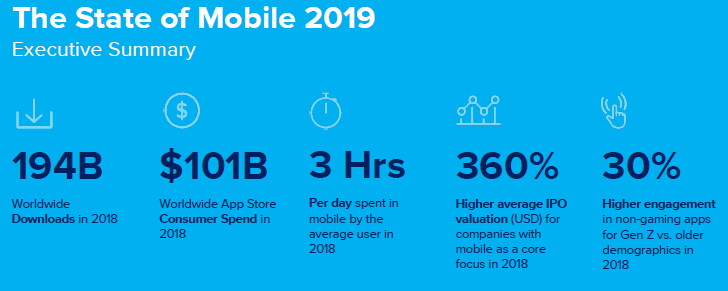

```python
Image(filename=os.path.join(IMAGES_PATH, 'statoMobile2019.png'), width=600)
```

Lo studo evidenzia come nel 2018 sono stati effettuati **194 miliardi di download** di applicazioni e giochi con una spesa complessiva di **101 miliardi di dollari**.  
Ogni utente, secondo le osservazioni ha trascorso in media **3 ore al giorno davanti** allo schermo.

Negli ultimi due anni, il numero di applicativi scaricati è cresciuto del **35%** nel mondo e nei mercati emergenti di Cina ed India, rispettivamente, del **70%** e del **165%**.

[figure not shown]

```python
Image(filename=os.path.join(IMAGES_PATH, 'CrescitaApp.png'), width=800)
```

La spesa dei consumatori in Applicazioni è di 101 miliardi di dollari nel 2018, in crescita del **75%** A partire dal 2016.  
Nei mercati emergenti, questa crescita è del tutto maggiore con il **140%** in Cina.

Il tempo trascorso utilizzando applicazioni mobili è cresciuto a livello globale **50%** dal 2016 al 2018.

[figure not shown]

```python
Image(filename=os.path.join(IMAGES_PATH, 'tempoSpeso.png'), width=700)
```

Le statistiche, precedentemente elencate, delineano in modo chiaro la crescita del mercato mobile.

Si sta, inoltre, affermando nel mondo il predominio della piattaforma mobile Android, sviluppata da Google.  
Si registrano a Maggio 2019 oltre **2,5 miliardi di dispositivi attivi** con sistema operativo Android. Le applicazioni in Android sono scaricate per lo più dallo store ufficiale **Google Play** che può contare nel primo quadrimestre del 2019 oltre **20,5 miliardi di download**.

**Caso di studio**:  
Si è, perciò, deciso di condurre uno studio su un DataSet riguardanti i dati del marketplace Android ed effettuare un'analisi predittiva sulla valutazione delle app in termini di punteggio (da 1 a 5).  
La strategia scelta per affrontare il problema è ricaduta verso gli **algoritmi di classificazione**, quindi intendiamo risolvere un problema di apprendimento supervisionato.

## Operazioni preliminari sui Dati

Si è iniziato lo studio sull'insieme di dati disponibili, esaminando il primo dataset contenente le applicazioni. Si sono visualizzate le prime colonne per uno studio immediato delle caratteristiche delle tuple presenti all'interno del Dataset.

```python
dataset1 = ps.read_csv("../ProgettoDM/googleplaystore.csv")
dataset1.head()
```

|  | App | Category | Rating | Reviews | Size | Installs | Type | Price | Content Rating | Genres | Last Updated | Current Ver | Android Ver |
| --- | --- | --- | --- | --- | --- | --- | --- | --- | --- | --- | --- | --- | --- |
| 0 | Photo Editor & Candy Camera & Grid & ScrapBook | ART_AND_DESIGN | 4.1 | 159 | 19M | 10,000+ | Free | 0 | Everyone | Art & Design | January 7, 2018 | 1.0.0 | 4.0.3 and up |
| 1 | Coloring book moana | ART_AND_DESIGN | 3.9 | 967 | 14M | 500,000+ | Free | 0 | Everyone | Art & Design;Pretend Play | January 15, 2018 | 2.0.0 | 4.0.3 and up |
| 2 | U Launcher Lite – FREE Live Cool Themes, Hide ... | ART_AND_DESIGN | 4.7 | 87510 | 8.7M | 5,000,000+ | Free | 0 | Everyone | Art & Design | August 1, 2018 | 1.2.4 | 4.0.3 and up |
| 3 | Sketch - Draw & Paint | ART_AND_DESIGN | 4.5 | 215644 | 25M | 50,000,000+ | Free | 0 | Teen | Art & Design | June 8, 2018 | Varies with device | 4.2 and up |
| 4 | Pixel Draw - Number Art Coloring Book | ART_AND_DESIGN | 4.3 | 967 | 2.8M | 100,000+ | Free | 0 | Everyone | Art & Design;Creativity | June 20, 2018 | 1.1 | 4.4 and up |

Si è esaminata innanzitutto la tipologia di valori presenti nel dataset, essi risultano per lo più di tipo "object" eccetto per il tipo "float" dell'attributo Rating.

```python
print(dataset1.info())
print(hrule(40))
print(dataset1.shape)
```

```
<class 'pandas.core.frame.DataFrame'>
RangeIndex: 10841 entries, 0 to 10840
Data columns (total 13 columns):
App               10841 non-null object
Category          10841 non-null object
Rating            9367 non-null float64
Reviews           10841 non-null object
Size              10841 non-null object
Installs          10841 non-null object
Type              10840 non-null object
Price             10841 non-null object
Content Rating    10840 non-null object
Genres            10841 non-null object
Last Updated      10841 non-null object
Current Ver       10833 non-null object
Android Ver       10838 non-null object
dtypes: float64(1), object(12)
memory usage: 1.1+ MB
None
========================================
(10841, 13)
```

Il primo passo è quello di rimuovere i duplicati che possono avere un impatto negativo nello studio da effettuare.

```python
dataset1.drop_duplicates('App',keep='first', inplace=True)
print(dataset1.shape)
```

```
(9660, 13)
```

```python
dataset1.drop(labels='Genres', axis=1, inplace=True)
#dataset1.head()
```

Sono state, inoltre, eliminate le colonne "Current Version" e "Android Version" poichè considerate non significative ai fini dell'analisi successiva.

```python
dataset1.drop(labels='Current Ver', axis=1, inplace=True)
dataset1.drop(labels='Android Ver', axis=1, inplace=True)
#dataset1.head()
```

Un primo importante passo dell'analisi eseguita è lo studio delle applicazioni divise per Categorie.

Successivamente è riportato un grafico che evidenzia il numero di Applicazioni per ogni Categoria del dataset in esame.

```
Saving figure App for Category
```

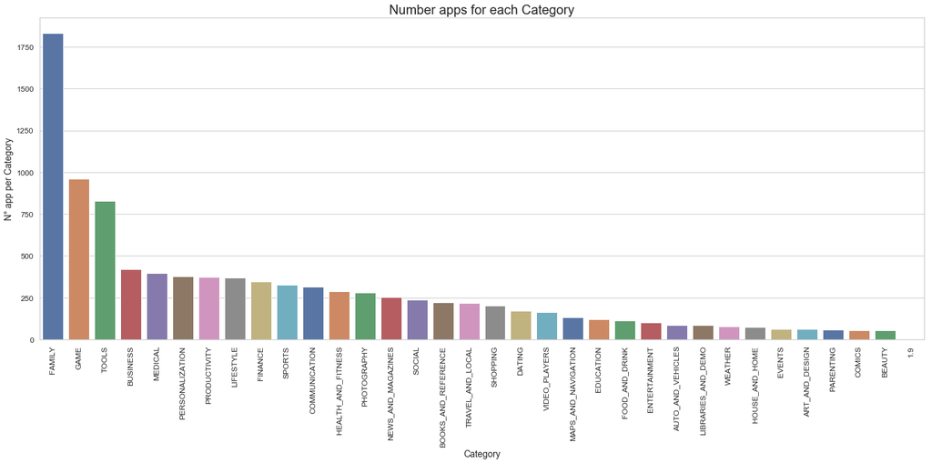

```python
plt.figure(figsize=(20,10))
sns.barplot(x=dataset1['Category'].value_counts().index, y=dataset1['Category'].value_counts(),palette='deep')
plt.ylabel("N° app per Category")
plt.xlabel("Category")
plt.title("Number apps for each Category",size = 20)
plt.xticks(rotation=90)
save_fig("App for Category")
```

Dall'esame del precedente grafico è possibile notare la presenza della categoria "1.9", essendo una categoria non usuale e considerando che ad essa era collegata una sola applicazione, si è proceduto ad eliminare la riga associata.

```python
riga = dataset1.loc[dataset1['Category']=='1.9']
dataset1.drop(labels=riga.index, axis =0, inplace=True )
#print(dataset1.loc[dataset1['Category']=='1.9'] )
```

Essendo lo studio basato sul Rating, si è scelto di eliminare le tuple con valore nullo all'interno del dataset.

```python
##daprovare questo###
#dataset1["Rating"] = dataset1.groupby("Category")["Rating"].transform(lambda x: x.fillna(x.mean()))
print(dataset1.isna().sum())
dataset1.dropna(inplace=True)
#print(dataset1.info())
```

```
App                  0
Category             0
Rating            1463
Reviews              0
Size                 0
Installs             0
Type                 1
Price                0
Content Rating       0
Last Updated         0
dtype: int64
```

Con le direttive successive è stato trasformato l'attributo Rating in un tipo "np.float". Sono presentati successivaente due grafici:

1. Il primo garfico studia la frequenza del Rating
2. Il secondo grafico esamina la distribuzione dei valori di Rating all'interno di ogni Category

```python
dataset1['Rating']= dataset1['Rating'].astype(np.float)
#dataset1.info()
```

```
Saving figure Rating Distribution
```

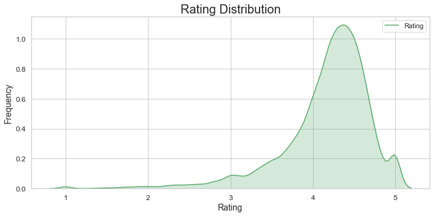

```python
plt.figure(figsize=(10,5))
sns.kdeplot(dataset1.Rating, color="g", shade = True)
plt.xlabel("Rating")
plt.ylabel("Frequency")
plt.title('Rating Distribution',size = 20)
save_fig("Rating Distribution")
```

```
Saving figure Ratings for each Category
```

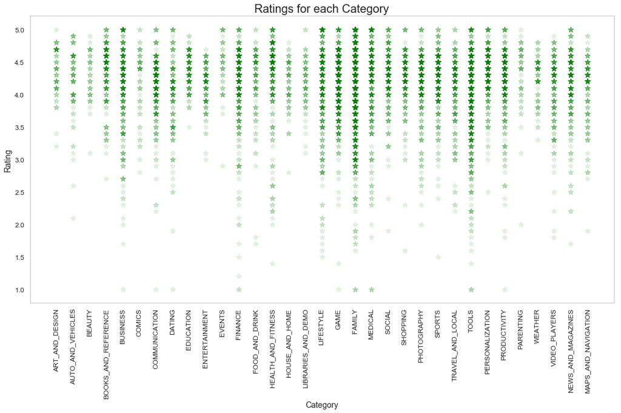

```python
plt.subplots(figsize=(15,10))
plt.scatter(x=dataset1['Category'],y=dataset1["Rating"],color="green",marker='*',s=100, alpha=0.1)
plt.xticks(rotation=90)
plt.grid()
plt.title('Ratings for each Category', size=20)
plt.ylabel('Rating')
plt.xlabel('Category')
save_fig("Ratings for each Category")
```

Di seguito è riportato un grafico che mette in relazione la fascia dei punteggi di Rating con i prezzi presenti all'interno della stessa.

Precedentemente si è trasformato il prezzo in un tipo "np.float".

```python
dataset1['Price']  = dataset1['Price'].str.replace('$', '')
dataset1['Price'] = dataset1['Price'].astype(float)
#dataset1['Price'].value_counts()
```

```
Saving figure Price changing in the rating
```

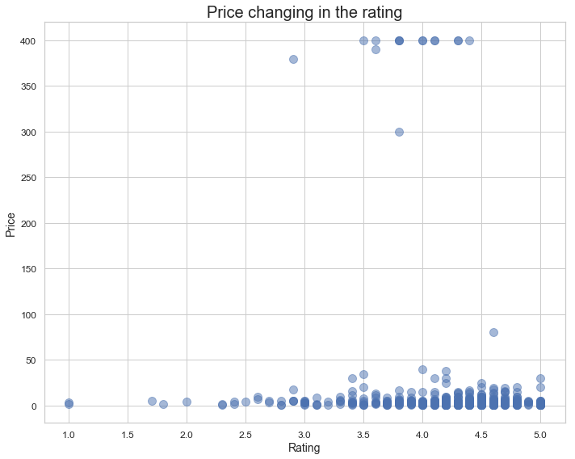

```python
paid = dataset1[dataset1['Price']>0]
paid.plot(kind = "scatter", x = "Rating", y = "Price", alpha = .5, color = "b", figsize=(10,8), s =100)
plt.xlabel("Rating")
plt.ylabel("Price")
plt.title("Price changing in the rating", size =20)
save_fig("Price changing in the rating")
```

Come è possibile notare dal grafico precedente vi sono alcune applicazioni aventi prezzo intorno ai 400$. Tali applicazioni rappresentano una minima parte del dataset, la loro presenza potrebbe inficiare l'efficacia dell'algoritmo di classificazione in quanto identificabili come "outlier".

```python
AppCostose=dataset1[dataset1['Price']>50]
AppCostose.head(20)
```

|  | App | Category | Rating | Reviews | Size | Installs | Type | Price | Content Rating | Last Updated |
| --- | --- | --- | --- | --- | --- | --- | --- | --- | --- | --- |
| 2253 | Vargo Anesthesia Mega App | MEDICAL | 4.6 | 92 | 32M | 1,000+ | Paid | 79.99 | Everyone | June 18, 2018 |
| 4197 | most expensive app (H) | FAMILY | 4.3 | 6 | 1.5M | 100+ | Paid | 399.99 | Everyone | July 16, 2018 |
| 4362 | 💎 I'm rich | LIFESTYLE | 3.8 | 718 | 26M | 10,000+ | Paid | 399.99 | Everyone | March 11, 2018 |
| 4367 | I'm Rich - Trump Edition | LIFESTYLE | 3.6 | 275 | 7.3M | 10,000+ | Paid | 400.00 | Everyone | May 3, 2018 |
| 5351 | I am rich | LIFESTYLE | 3.8 | 3547 | 1.8M | 100,000+ | Paid | 399.99 | Everyone | January 12, 2018 |
| 5354 | I am Rich Plus | FAMILY | 4.0 | 856 | 8.7M | 10,000+ | Paid | 399.99 | Everyone | May 19, 2018 |
| 5355 | I am rich VIP | LIFESTYLE | 3.8 | 411 | 2.6M | 10,000+ | Paid | 299.99 | Everyone | July 21, 2018 |
| 5356 | I Am Rich Premium | FINANCE | 4.1 | 1867 | 4.7M | 50,000+ | Paid | 399.99 | Everyone | November 12, 2017 |
| 5357 | I am extremely Rich | LIFESTYLE | 2.9 | 41 | 2.9M | 1,000+ | Paid | 379.99 | Everyone | July 1, 2018 |
| 5358 | I am Rich! | FINANCE | 3.8 | 93 | 22M | 1,000+ | Paid | 399.99 | Everyone | December 11, 2017 |
| 5359 | I am rich(premium) | FINANCE | 3.5 | 472 | 965k | 5,000+ | Paid | 399.99 | Everyone | May 1, 2017 |
| 5362 | I Am Rich Pro | FAMILY | 4.4 | 201 | 2.7M | 5,000+ | Paid | 399.99 | Everyone | May 30, 2017 |
| 5364 | I am rich (Most expensive app) | FINANCE | 4.1 | 129 | 2.7M | 1,000+ | Paid | 399.99 | Teen | December 6, 2017 |
| 5366 | I Am Rich | FAMILY | 3.6 | 217 | 4.9M | 10,000+ | Paid | 389.99 | Everyone | June 22, 2018 |
| 5369 | I am Rich | FINANCE | 4.3 | 180 | 3.8M | 5,000+ | Paid | 399.99 | Everyone | March 22, 2018 |
| 5373 | I AM RICH PRO PLUS | FINANCE | 4.0 | 36 | 41M | 1,000+ | Paid | 399.99 | Everyone | June 25, 2018 |

Si mostra di seguito un grafico che analizza la frequenza per i prezzi rilevati.

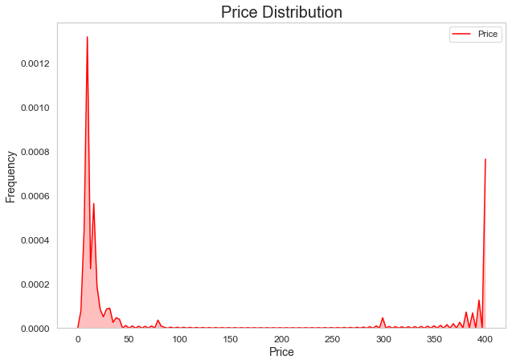

```
Saving figure Price Distribution.png
```

```python
plt.figure(figsize=(10,7))
g = sns.kdeplot(dataset1.Price, shade=True,color='red')
plt.grid()
plt.ylabel('Frequency')
plt.xlabel('Price')
plt.title("Price Distribution", size=20)
plt.show()
figure = g.get_figure()
#save_figure("Frequency of price")
save_figure(figure,"Price Distribution.png")
```

Dato che si è scelto di utilizzare il Rating come classe da predire, categorizziamo lo stesso in 5 classi.

```python
dataset1['Rating'] = ps.cut(dataset1['Rating'], bins=[0.9,1.9,2.9,3.9,4.9,np.inf],labels=['1','2','3','4','5'])
dataset1['Rating'] = dataset1['Rating'].astype(int)
```

Successivamente si è applicata la trasformazione dei valori dell'attributo Reviews in interi.

Si è graficato il numero di Recesioni per ogni Category.

```python
dataset1['Reviews']=dataset1['Reviews'].astype(np.int64)
#dataset1.info()
```

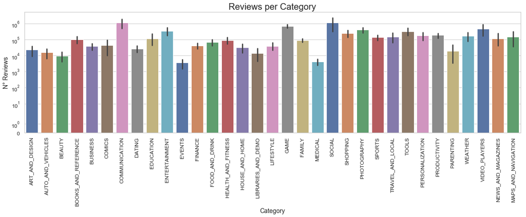

```
Saving figure Reviews per Category
```

```python
plt.figure(figsize=(20,5))
fig = sns.barplot(x=dataset1['Category'], y=dataset1['Reviews'],palette='deep')
plt.xticks(rotation=90)
plt.xlabel('Category')
plt.ylabel('N° Reviews')
fig.set_yscale('symlog')
plt.title('Reviews per Category', size=20)
plt.show()
figure = fig.get_figure()
save_figure(figure, "Reviews per Category")
```

Di seguito si è applicata la trasformazione dei valori di Install in tipo "np.int".

Si è graficato il numero di Install per ogni Category.

```python
dataset1['Installs'].value_counts()
install = dataset1['Installs'].str.replace('+',' ')
install = install.str.replace(',','')
dataset1['Installs'] = install.astype(np.int)
```

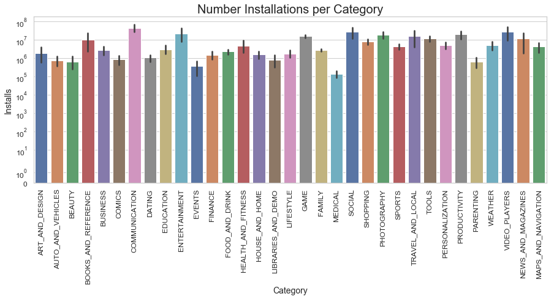

```
Saving figure Number Installations per Category
```

```python
plt.figure(figsize=(15,5))
fig = sns.barplot(x=dataset1['Category'], y=dataset1['Installs'], palette='deep')
plt.xticks(rotation=90)
plt.ylabel('Installs')
plt.xlabel('Category')
fig.set_yscale('symlog')
plt.title('Number Installations per Category', size=20)
plt.show()
figure = fig.get_figure()
save_figure(figure, "Number Installations per Category")
```

Si è applicata la conversione del prezzo in numero e in seguito si è esposto un grafico che mette in relazione il numero di applicazioni gratis e a pagamento.

```
Saving figure Free-Paid
```

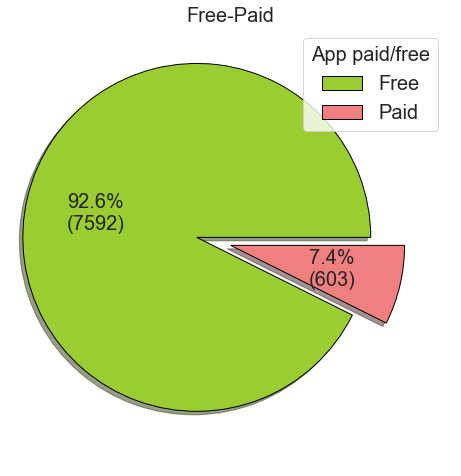

```python
#free = dataset1[dataset1['Price']== 0]
#paid = dataset1[dataset1['Price'] > 0]
free= dataset1.groupby('Type').count()
plt.figure(figsize=(12,8))

def func(pct, allvals):
    absolute = int(pct/100.*np.sum(allvals))
    return "{:.1f}%\n({:d})".format(pct, absolute)

wedges, texts, autotexts = plt.pie(free.App, explode=(0.2,0), autopct=lambda pct: func(pct, free.App), shadow=True,colors=['yellowgreen','lightcoral'],wedgeprops = {'linewidth': 1,'edgecolor' :'black'})
legend = plt.legend(wedges, free.index,title="App paid/free",loc="best", prop={'size': 20})
plt.setp(legend.get_title(), fontsize='20')
plt.setp(autotexts, size=20)
plt.title("Free-Paid", size=20)
save_fig("Free-Paid", False)
```

Categorizziamo l'attributo Type, con interi 0 per le app gratis e 1 per le app a pagamento.

```python
dataset1['Type'] = dataset1['Type'].map({'Free':0,'Paid':1})
```

Si esegue la conversione dell'attributo Size in "np.float", si utilizzerà come unità di misura i Byte, pertanto i suffissi M e K fungeranno da coefficenti di moltiplicazione rispettivamente dei valori 1.000.000 e 1.000.

Alle applicazioni che hanno una "Size" dipendente dal dispositivo sarà assegnata la media degli altri valori di "Size"

```python
#dataset1['Size'].value_counts()
stringhe = dataset1['Size'].str.extract(pat='([0-9]+\.*[0-9]*)([A-Za-z]*)|(^[A-Za-z\s]+)')
#print(stringhe.values)
#print(hrule(30))
stringhe.iloc[:,1].replace(to_replace='M', value=1000000, inplace=True)
stringhe.iloc[:,1].replace(to_replace='k', value=1000, inplace=True)
stringhe.iloc[:,1].replace(to_replace='K', value=1000, inplace=True)
stringhe.iloc[:,0] = stringhe.iloc[:,0].astype(np.float)
stringhe.iloc[:,1] = stringhe.iloc[:,1].astype(np.float)
stringhe.iloc[:,0] = stringhe.iloc[:,0].mul(stringhe.iloc[:,1])
media = stringhe.iloc[:,0].mean(skipna=True)
stringhe.iloc[:,0].fillna(media, inplace=True)
#print(stringhe, media)
dataset1['Size'] = stringhe.iloc[:,0]
dataset1['Size'] = dataset1['Size'].astype(int)
#print(dataset1['Size'].unique())
#dataset1.info()
```

Un passo fondamentale è lo studio della correlazione fra i vari attributi presenti nel dataset. Non si evidenziano particolari criticità.

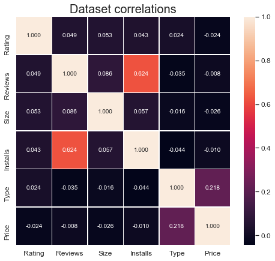

```
Saving figure Dataset correlations
```

```python
fig,ax = plt.subplots(figsize=(8,7))
fig = sns.heatmap(dataset1.corr(), annot=True,linewidths=.5,fmt='.3f')
plt.title("Dataset correlations", size=20)
plt.show()
figure = fig.get_figure()
save_figure(figure, "Dataset correlations")
```

Si sono convertite le Category mediante la conversione data dal trasformatore OneHotEncoder di Pandas. Per ogni Category sarà generato un attributo all'interno del Dataset con valore 1 se la tupla appartiene alla Categoria, 0 altrimenti.

```python
oneHot = ps.get_dummies(dataset1['Category'])
dataset1= dataset1.join(oneHot)
dataset1.drop(labels='Category', axis=1, inplace=True)
```

Si è convertito l'attributo Content Rating mediante la conversione di OneHotEncoder di Pandas.

```python
dataset1['Content Rating'].unique()
#print(dataset1['Content Rating'].value_counts())
oneHot2 = ps.get_dummies(dataset1['Content Rating'])
dataset1= dataset1.join(oneHot2)
dataset1.drop(labels='Content Rating', axis=1, inplace=True)
#dataset1.info()
```

Viene effettuata una conversione del campi "Last Update", la iesima data è ottenuta come differenza fra esse e la data di creazione del PlayStore identificata dal 22 ottobre 2008.

```python
dataset1['Last Updated']= ps.to_datetime(dataset1['Last Updated'])
dataCreazionePlayStore = ps.to_datetime('October 22, 2008')
dataset1['Last Updated'] =((dataset1['Last Updated'] -dataCreazionePlayStore )  / np.timedelta64(1,'D'))
#print(dataset1.head())
#print(hrule(30))
#print(dataset1.info())
```

```python
dataset1Appendice = dataset1.copy(True)
dataset1Appendice.info()
```

```
<class 'pandas.core.frame.DataFrame'>
Int64Index: 8196 entries, 0 to 10840
Data columns (total 47 columns):
App                    8196 non-null object
Rating                 8196 non-null int32
Reviews                8196 non-null int64
Size                   8196 non-null int32
Installs               8196 non-null int32
Type                   8196 non-null int64
Price                  8196 non-null float64
Last Updated           8196 non-null float64
ART_AND_DESIGN         8196 non-null uint8
AUTO_AND_VEHICLES      8196 non-null uint8
BEAUTY                 8196 non-null uint8
BOOKS_AND_REFERENCE    8196 non-null uint8
BUSINESS               8196 non-null uint8
COMICS                 8196 non-null uint8
COMMUNICATION          8196 non-null uint8
DATING                 8196 non-null uint8
EDUCATION              8196 non-null uint8
ENTERTAINMENT          8196 non-null uint8
EVENTS                 8196 non-null uint8
FAMILY                 8196 non-null uint8
FINANCE                8196 non-null uint8
FOOD_AND_DRINK         8196 non-null uint8
GAME                   8196 non-null uint8
HEALTH_AND_FITNESS     8196 non-null uint8
HOUSE_AND_HOME         8196 non-null uint8
LIBRARIES_AND_DEMO     8196 non-null uint8
LIFESTYLE              8196 non-null uint8
MAPS_AND_NAVIGATION    8196 non-null uint8
MEDICAL                8196 non-null uint8
NEWS_AND_MAGAZINES     8196 non-null uint8
PARENTING              8196 non-null uint8
PERSONALIZATION        8196 non-null uint8
PHOTOGRAPHY            8196 non-null uint8
PRODUCTIVITY           8196 non-null uint8
SHOPPING               8196 non-null uint8
SOCIAL                 8196 non-null uint8
SPORTS                 8196 non-null uint8
TOOLS                  8196 non-null uint8
TRAVEL_AND_LOCAL       8196 non-null uint8
VIDEO_PLAYERS          8196 non-null uint8
WEATHER                8196 non-null uint8
Adults only 18+        8196 non-null uint8
Everyone               8196 non-null uint8
Everyone 10+           8196 non-null uint8
Mature 17+             8196 non-null uint8
Teen                   8196 non-null uint8
Unrated                8196 non-null uint8
dtypes: float64(2), int32(3), int64(2), object(1), uint8(39)
memory usage: 792.4+ KB
```

```python
dataset1.drop(labels='App', axis=1, inplace=True )
```

## Training dei Classificatori

Creiamo un Dafaframe nel quale inserire i risultati dei test condotti e salvarlo su file.

```python
#dataResults= ps.DataFrame(columns=['Classifier', 'Accuracy Average', 'Recall Average','Precision Average', 'Type'] )
#print(dataResults.head())

def carica(name, accuracy,recall, precision, tipo):

    dataResults = ps.read_csv("../progettoDM/result.csv")
    dict = {
      "Classifier": name,
      "Accuracy Average": accuracy,
      "Recall Average": recall,
      'Precision Average': precision,
      'Type':tipo
      }
    dataResults=dataResults.append(dict, ignore_index=True)
    #print(dict_)
    #dataResults = ps.concat([dict_, dataResults]).reset_index(drop = True)
    #dataResults = dataResults.append(dict,ignore_index=True)
    dataResults.to_csv("../progettoDM/result.csv",index=False)
    #print(dataResults.head())
    return dataResults
```

Siccome affrontiamo un problema di classificazione multi-classe riadattiamo le metriche di valutazione degli algoritmi di classificazione in base alle nostre esigenze e per agevolarne l'uso.

```python
from sklearn.model_selection import *
from sklearn.metrics import *

def accuracy_media(y_pred,y_train):
    somma = 0
    for i in range(1,6):
        y_train_i = np.where(y_train == i, True, False)
        y_pred_i = np.where(y_pred == i, True, False)
        score = accuracy_score(y_train_i, y_pred_i)
        somma += score
    average=somma / 5
    print("The Accuracy Average is:",average,"\n")
    return average

def recall_media(y_pred,y_train):
    '''somma = 0
    for i in range(1,6):
        y_train_i = np.where(y_train == i, True, False)
        y_pred_i = np.where(y_pred == i, True, False)
        score = recall_score(y_train_i, y_pred_i)
        somma += score
    average=somma / 5'''
    average=recall_score(y_train,y_pred, labels=[1,2,3,4,5],average='weighted')
    print("The Recall Average is:",average,"\n")
    return average

def precision_media(y_pred,y_train):
    '''  somma = 0
    for i in range(1,6):
        y_train_i = np.where(y_train == i, True, False)
        y_pred_i = np.where(y_pred == i, True, False)
        score = precision_score(y_train_i, y_pred_i)
        somma += score'''
    average=precision_score(y_train,y_pred, labels=[1,2,3,4,5],average='weighted')
    #average=somma / 5
    print("The Precision Average is:",average,"\n")
    return average


def roc_media(y_pred,y_train):
    somma = 0
    for i in range(1,6):
        y_train_i = np.where(y_train == i, True, False)
        y_pred_i = np.where(y_pred == i, True, False)
        score = roc_auc_score(y_train_i, y_pred_i)
        somma += score
    average=somma / 5
    print("The ROC Average is:",average,"\n")
    return average

def compute_Average(y_pred,y_train):
    return (accuracy_media(y_pred,y_train),recall_media(y_pred,y_train),precision_media(y_pred,y_train))
    #roc_media(y_train,y_pred)

import pickle
```

Diviamiamo il nostro dataset in test set e training set

```python
#print(dataset1.head())
#print(hrule(40))
Y = dataset1['Rating']
X = dataset1.drop('Rating', axis=1)
from sklearn.model_selection import train_test_split
X_train, X_test, y_train, y_test = train_test_split(X,Y, test_size=0.2, random_state=42)
print(X_train.shape, y_train.shape, X_test.shape, y_test.shape)
print(hrule(40))
#print(X_train.info(), y_train.describe())
```

```
(6556, 45) (6556,) (1640, 45) (1640,)
========================================
```

**SGDClassifier**

Questo stimatore fa parte dei modelli di apprendimento supervisionato e implementa modelli lineari regolarizzati utilizzando la discesa stocastica del gradiente (stochastic gradient descent, SGD) come metrica di apprendimento. La funzione di perdita (o errore) viene stimata per ogni campione alla volta secondo un rate di apprendimento. SGD è applicato con successo a problemi di apprendimento automatico su larga scala e sparsi che si incontrano spesso nella classificazione del testo e nell'elaborazione del linguaggio naturale. I vantaggi di Stochastic Gradient Descent sono:

1. Efficienza
2. Facilità di implementazione
3. Ottimizzazione del codice

Gli svantaggi di SGD sono:

1. SGD richiede numerosi iperparametri come il parametro di regolarizzazione e il numero di iterazioni.
2. SGD è sensibile al ridimensionamento.

Allenamento Classificatore:

```python
#from sklearn.linear_model import SGDClassifier
#sgd_clf= SGDClassifier(max_iter=1000, tol=-np.infty, random_state=42)
#sgd_clf.fit(X_train, y_train)
#y_pred= sgd_clf.predict(X_train)

# save the model to disk
filename = './Model/sgd_clf.sav'
#pickle.dump(sgd_clf, open(filename, 'wb'))

# load the model from disk
sgd_clf = pickle.load(open(filename, 'rb'))
print(sgd_clf)
```

```
SGDClassifier(alpha=0.0001, average=False, class_weight=None,
       early_stopping=False, epsilon=0.1, eta0=0.0, fit_intercept=True,
       l1_ratio=0.15, learning_rate='optimal', loss='hinge', max_iter=1000,
       n_iter=None, n_iter_no_change=5, n_jobs=None, penalty='l2',
       power_t=0.5, random_state=42, shuffle=True, tol=-inf,
       validation_fraction=0.1, verbose=0, warm_start=False)
```

Verifica delle prestazioni sul TrainSet:

```python
y_pred_sgd= sgd_clf.predict(X_train)
accuracy,recall, precision = compute_Average(y_pred_sgd,y_train)
name="SGD"
#dataResults = carica(name, accuracy,recall, precision, 'train')
```

```
The Accuracy Average is: 0.8931055521659548

The Recall Average is: 0.7327638804148872

The Precision Average is: 0.6548406991398994
```

Verifica delle prestazioni sul Test Set:

```python
y_pred_sgd= sgd_clf.predict(X_test)
accuracy,recall, precision = compute_Average(y_pred_sgd,y_test)
name="SGD"
#dataResults = carica(name, accuracy,recall, precision, 'test')
```

```
The Accuracy Average is: 0.8892682926829268

The Recall Average is: 0.723170731707317

The Precision Average is: 0.6534058585002723
```

Proviamo ad ottenere una configurazione migliore con GridSearch:

```python
'''param_sgd_grid = {
    'loss': ['hinge', 'log', 'modified_huber', 'squared_hinge', 'perceptron'],
    'penalty': ['l2','elasticnet', 'l1'],
}
grid_search = GridSearchCV(sgd_clf, param_sgd_grid, cv=10,scoring='accuracy', return_train_score=True)
grid_search.fit(X_train, y_train)
print("Best Param:", grid_search.best_params_)
best_sgd_clf = grid_search.best_estimator_

# save the model to disk
filename = './Model/best_sgd_clf.sav'
pickle.dump(best_sgd_clf, open(filename, 'wb'))'''

filename = './Model/best_sgd_clf.sav'
# load the model from disk
best_sgd_clf = pickle.load(open(filename, 'rb'))
print(best_sgd_clf)
```

```
SGDClassifier(alpha=0.0001, average=False, class_weight=None,
       early_stopping=False, epsilon=0.1, eta0=0.0, fit_intercept=True,
       l1_ratio=0.15, learning_rate='optimal', loss='log', max_iter=1000,
       n_iter=None, n_iter_no_change=5, n_jobs=None, penalty='l2',
       power_t=0.5, random_state=42, shuffle=True, tol=-inf,
       validation_fraction=0.1, verbose=0, warm_start=False)
```

Verifica delle prestazioni sul Train Set dopo la ricerca dei parametri:

```python
y_pred_sgd= best_sgd_clf.predict(X_train)
accuracy,recall, precision = compute_Average(y_pred_sgd,y_train)
name="GridSGD"
#dataResults = carica(name, accuracy,recall, precision, 'train')
```

```
The Accuracy Average is: 0.8931665649786454

The Recall Average is: 0.7329164124466138

The Precision Average is: 0.6546797213279258
```

Verifica delle prestazioni sul Test Set dopo la ricerca dei parametri:

```python
y_pred_sgd= best_sgd_clf.predict(X_test)
accuracy,recall, precision = compute_Average(y_pred_sgd,y_test)
name="GridSGD"
#dataResults = carica( name, accuracy,recall, precision, 'test')
```

```
The Accuracy Average is: 0.8897560975609755

The Recall Average is: 0.724390243902439

The Precision Average is: 0.6616945477075588
```

**Knn Classifier**

E' un algoritmo, del tipo supervisionato, utilizzato nel riconoscimento di pattern per la classificazione di oggetti basandosi sulle caratteristiche degli oggetti vicini a quello considerato. La classificazione è calcolata tramite un voto di maggioranza dei punti più vicini, viene assegnata la classe al punto considerato grazie alla classe dei k rappresentanti più vicini. I vantaggi si questo classificatore sono:

1. sopprime gli effetti del rumore
2. confini della classificazione meno distinti

Lo svantaggio principale dell'algoritmo KNN è che è di tipo "lazy Learner", cioè non apprende alcun chè dal training set e semplicemente utilizza il training set per la classificazione. Per prevedere l'etichetta di una nuova istanza, l'algoritmo KNN troverà i vicini più vicini K alla nuova istanza dai dati di addestramento, l'etichetta di classe prevista verrà quindi impostata come l'etichetta più comune tra i punti vicini K più vicini. Lo svantaggio principale di questo approccio è che l'algoritmo deve calcolare la distanza e ordinare il training set a ogni previsione. Knn è algoritmo non robusto a dati rumorosi.

Allenamento Classificatore:

```python
'''from sklearn.neighbors import KNeighborsClassifier
knn_clf = KNeighborsClassifier(n_neighbors=5, weights='uniform',leaf_size=30)
knn_clf.fit(X_train,y_train)

# save the model to disk
filename = 'knn_clf.sav'
pickle.dump(knn_clf, open(filename, 'wb'))'''

# load the model from disk
filename = './Model/knn_clf.sav'
knn_clf = pickle.load(open(filename, 'rb'))
print(knn_clf)
```

```
KNeighborsClassifier(algorithm='auto', leaf_size=30, metric='minkowski',
           metric_params=None, n_jobs=None, n_neighbors=5, p=2,
           weights='uniform')
```

Verifica delle prestazioni sul TrainSet:

```python
y_pred_knn= knn_clf.predict(X_train)
accuracy,recall, precision = compute_Average(y_pred_knn,y_train)
name = 'KNN'
#dataResults = carica( name, accuracy,recall, precision, 'train')
```

```
The Accuracy Average is: 0.9086638194020743

The Recall Average is: 0.7716595485051861

The Precision Average is: 0.7413682572814398
```

Verifica delle prestazioni sul Test Set

```python
y_pred_knn= knn_clf.predict(X_test)
accuracy,recall, precision = compute_Average(y_pred_knn,y_test)
name = 'KNN'
#dataResults = carica( name, accuracy,recall, precision, 'test')
```

```
The Accuracy Average is: 0.8751219512195123

The Recall Average is: 0.6878048780487804

The Precision Average is: 0.6282311523165182
```

Proviamo ad ottenere una configurazione migliore con GridSearch:

```python
'''param_knn_grid = {
    'n_neighbors': [5,10,15,20,50],
    'weights': ['uniform','distance'],
    'leaf_size': [20,30,50]
}
grid_search = GridSearchCV(knn_clf, param_knn_grid, cv=10,scoring='accuracy', return_train_score=True)
grid_search.fit(X_train, y_train)
print("Best Param:", grid_search.best_params_)
best_knn_clf = grid_search.best_estimator_

# save the model to disk
filename = 'best_knn_clf.sav'
pickle.dump(best_knn_clf, open(filename, 'wb'))'''

# load the model from disk
filename = './Model/best_knn_clf.sav'
best_knn_clf = pickle.load(open(filename, 'rb'))
print(best_knn_clf)
```

```
KNeighborsClassifier(algorithm='auto', leaf_size=20, metric='minkowski',
           metric_params=None, n_jobs=None, n_neighbors=50, p=2,
           weights='uniform')
```

Verifica delle prestazioni sul TrainSet dopo la ricerca dei parametri:

```python
y_pred_knn= best_knn_clf.predict(X_train)
accuracy,recall, precision = compute_Average(y_pred_knn,y_train)
name='GridKNN'
#dataResults = carica( name, accuracy,recall, precision, 'train')
```

```
The Accuracy Average is: 0.8946308724832216

The Recall Average is: 0.7365771812080537

The Precision Average is: 0.542545943876402
```

Verifica delle prestazioni sul Test Set dopo la ricerca dei parametri:

```python
y_pred_knn= best_knn_clf.predict(X_test)
accuracy,recall, precision = compute_Average(y_pred_knn,y_test)
name='GridKNN'
#dataResults = carica( name, accuracy,recall, precision, 'test')
```

```
The Accuracy Average is: 0.8892682926829268

The Recall Average is: 0.723170731707317

The Precision Average is: 0.5229759071980964
```

**SVC**

Le macchine a vettori di supporto (SVM, dall'inglese Support-Vector Machines) sono dei modelli di apprendimento supervisionato che utilizzano classificatori lineari non probabilistici. SVC utilizza una rappresentazione degli esempi come punti nello spazio cercando di costruire un iperpiano o un insieme di iperpiani in uno spazio a più dimensioni. Una buona classificazione si può ottenere dall'iperpiano che ha la distanza maggiore dal punto più vicino di ognuna delle classi; in generale maggiore è il margine fra questi punti, minore è l'errore di generalizzazione commesso dal classificatore. I vantaggi delle macchine di supporto vettoriale sono:

1. Efficace in spazi di dimensioni elevate
2. Efficace quando il numero di dimensioni è maggiore del numero di campioni
3. Efficiente in termini di memoria: utilizza un sottoinsieme di punti di allenamento nella funzione decisionale
4. Versatile: diverse funzioni del kernel possono essere specificate per la funzione decisionale

Lo svantaggio principale dell'algoritmo SVM è che ha diversi parametri chiave che devono essere impostati correttamente per ottenere i migliori risultati di classificazione per ogni problema. I parametri che possono portare ad un'eccellente precisione per il problema A, possono comportare una scarsa precisione per il problema B. L'utente può, quindi, dover sperimentare un numero di diverse impostazioni dei parametri per ottenere un risultato soddisfacente.

Allenamento Classificatore:

```python
'''from sklearn.svm import SVC
svc_clf = SVC(gamma='auto', random_state=42)
svc_clf.fit(X_train,y_train)

# save the model to disk
filename = 'svc_clf.sav'
pickle.dump(svc_clf, open(filename, 'wb'))'''

# load the model from disk
filename = './Model/svc_clf.sav'
svc_clf = pickle.load(open(filename, 'rb'))
print(svc_clf)
```

```
SVC(C=1.0, cache_size=200, class_weight=None, coef0=0.0,
  decision_function_shape='ovr', degree=3, gamma='auto', kernel='rbf',
  max_iter=-1, probability=False, random_state=42, shrinking=True,
  tol=0.001, verbose=False)
```

Verifica delle prestazioni sul TrainSet:

```python
y_pred_svc= svc_clf.predict(X_train)
accuracy,recall, precision = compute_Average(y_pred_svc,y_train)
name = 'SVC'
#dataResults = carica( name, accuracy,recall, precision, 'train')
```

```
The Accuracy Average is: 0.9992678462477119

The Recall Average is: 0.9981696156192801

The Precision Average is: 0.9981718138275213
```

Verifica delle prestazioni sul Test Set

```python
y_pred_svc= svc_clf.predict(X_test)
accuracy,recall, precision = compute_Average(y_pred_svc,y_test)
#dataResults = carica( name, accuracy,recall, precision, 'test')
```

```
The Accuracy Average is: 0.8892682926829268

The Recall Average is: 0.723170731707317

The Precision Average is: 0.6277461359778432
```

Per questo classificatore non è stato ossibile eseguire algoritmi di tuning per elevate complessità computazionali.

**Decision Tree**

Fa parte dei metodi di apprendimento supervisionato il cui obiettivo è creare un modello che preveda il valore di una variabile target apprendendo semplici regole decisionali dedotte dalle caratteristiche dei dati rappresentate tramite un albero. I vantaggi di usare questo algoritmo sono:

1. Semplicità da capire e da interpretare l'albero.
2. Richiede una scarsa preparazione dei dati.
3. Il costo della previsione dei dati è logaritmico nel numero di punti utilizzati per addestrare il modello.
4. In grado di gestire sia dati numerici che categoriali.

Gli svantaggi degli alberi decisionali includono:

1. I costruttori possono creare alberi troppo complessi che non generalizzano bene i dati, quindi Overfitting.
2. Gli alberi decisionali possono essere instabili perché piccole variazioni nei dati potrebbero causare la generazione di un albero completamente diverso. Questo problema viene mitigato usando gli alberi decisionali all'interno di un Ensemble,
3. Il problema dell'apprendimento di un albero decisionale ottimale è noto per essere NP-completo sotto diversi aspetti dell'ottimalità e persino per concetti semplici. Di conseguenza, gli algoritmi pratici di apprendimento delle decisioni sono basati su algoritmi euristici come algoritmi Greedy in cui vengono prese decisioni localmente ottimali su ciascun nodo.
4. I costruttori degli alberi decisioniali producono alberi distorti se dominano alcune classi. Si raccomanda quindi di bilanciare il set di dati prima del montaggio con l'albero decisionale.

Allenamento Classificatore:

```python
'''from sklearn.tree import DecisionTreeClassifier

dc_clf = DecisionTreeClassifier()
dc_clf.fit(X_train,y_train)

# save the model to disk
filename = 'dc_clf.sav'
pickle.dump(dc_clf, open(filename, 'wb'))
'''
# load the model from disk
filename = './Model/dc_clf.sav'
dc_clf = pickle.load(open(filename, 'rb'))
print(dc_clf)
```

```
DecisionTreeClassifier(class_weight=None, criterion='gini', max_depth=None,
            max_features=None, max_leaf_nodes=None,
            min_impurity_decrease=0.0, min_impurity_split=None,
            min_samples_leaf=1, min_samples_split=2,
            min_weight_fraction_leaf=0.0, presort=False, random_state=None,
            splitter='best')
```

Verifica delle prestazioni sul TrainSet:

```python
y_pred_dc= dc_clf.predict(X_train)
accuracy, recall, precision = compute_Average(y_pred_dc,y_train)
name = 'DecisionTree'
#dataResults = carica( name, accuracy,recall, precision, 'train')
```

```
The Accuracy Average is: 1.0

The Recall Average is: 1.0

The Precision Average is: 1.0
```

Verifica delle prestazioni sul Test Set

```python
y_pred_dc= dc_clf.predict(X_test)
accuracy, recall, precision = compute_Average(y_pred_dc,y_test)
#dataResults = carica( name, accuracy,recall, precision, 'test')
```

```
The Accuracy Average is: 0.8565853658536586

The Recall Average is: 0.6414634146341464

The Precision Average is: 0.6444844566192024
```

Proviamo ad ottenere una configurazione migliore con GridSearch:

```python
'''from sklearn.model_selection import GridSearchCV
param_dc_grid = {
    'criterion': ['gini', 'entropy'],
    'splitter': ['best', 'random'],
}

grid_search = GridSearchCV(dc_clf, param_dc_grid, cv=10,
                           scoring='accuracy', return_train_score=True)
grid_search.fit(X_train, y_train)
print("Best Param:", grid_search.best_params_)
best_dc_clf = grid_search.best_estimator_

# save the model to disk
filename = 'best_dc_clf.sav'
pickle.dump(best_dc_clf, open(filename, 'wb'))'''

# load the model from disk
filename = './Model/best_dc_clf.sav'
best_dc_clf = pickle.load(open(filename, 'rb'))
print(best_dc_clf)
```

```
DecisionTreeClassifier(class_weight=None, criterion='gini', max_depth=None,
            max_features=None, max_leaf_nodes=None,
            min_impurity_decrease=0.0, min_impurity_split=None,
            min_samples_leaf=1, min_samples_split=2,
            min_weight_fraction_leaf=0.0, presort=False, random_state=None,
            splitter='best')
```

Verifica delle prestazioni sul TrainSet:

```python
y_pred_dc= best_dc_clf.predict(X_train)
accuracy, recall, precision = compute_Average(y_pred_dc,y_train)
name = 'GridDecisionTree'
#dataResults = carica( name, accuracy,recall, precision, 'train')
```

```
The Accuracy Average is: 1.0

The Recall Average is: 1.0

The Precision Average is: 1.0
```

Verifica delle prestazioni sul Test Set

```python
y_pred_dc= best_dc_clf.predict(X_test)
accuracy, recall, precision = compute_Average(y_pred_dc,y_test)
#dataResults = carica( name, accuracy,recall, precision, 'test')
```

```
The Accuracy Average is: 0.8573170731707316

The Recall Average is: 0.6432926829268293

The Precision Average is: 0.6472285935221442
```

**Logistic Regression**

Il Logistic Regression è un modello lineare per la classificazione. In questo modello, le probabilità che descrivono i possibili risultati di una singola prova sono modellate usando una funzione logistica. I vantaggi nell'utilizzare tale modello sono:

1. Facile estensione alla classificazione Multilabel
2. Calcolo delle probabilità di assegnamento ad una data classe, durante la predizione

Allenamento Classificatore:

```python
'''from sklearn.linear_model import LogisticRegression
logreg_clf = LogisticRegression(solver='lbfgs',multi_class='ovr')
logreg_clf.fit(X_train, y_train)

# save the model to disk
filename = 'logreg_clf.sav'
pickle.dump(logreg_clf, open(filename, 'wb'))'''

# load the model from disk
filename = './Model/logreg_clf.sav'
logreg_clf = pickle.load(open(filename, 'rb'))
print(logreg_clf)
```

```
LogisticRegression(C=1.0, class_weight=None, dual=False, fit_intercept=True,
          intercept_scaling=1, max_iter=100, multi_class='ovr',
          n_jobs=None, penalty='l2', random_state=None, solver='lbfgs',
          tol=0.0001, verbose=0, warm_start=False)
```

Verifica delle prestazioni sul TrainSet:

```python
y_pred_logreg= logreg_clf.predict(X_train)
accuracy, recall, precision = compute_Average(y_pred_logreg,y_train)
name = 'LogReg'
#dataResults = carica( name, accuracy,recall, precision, 'train')
```

```
The Accuracy Average is: 0.8946308724832216

The Recall Average is: 0.7365771812080537

The Precision Average is: 0.6408829565289297
```

Verifica delle prestazioni sul Test Set

```python
y_pred_logreg= logreg_clf.predict(X_test)
accuracy, recall, precision = compute_Average(y_pred_logreg,y_test)
#dataResults = carica( name, accuracy,recall, precision, 'test')
```

```
The Accuracy Average is: 0.8892682926829268

The Recall Average is: 0.723170731707317

The Precision Average is: 0.5229759071980964
```

Proviamo ad ottenere una configurazione migliore con GridSearch:

```python
'''
param_logreg_grid = [ {'penalty': ['l2'], 'solver': ['newton-cg', 'sag','lbfgs']},]
grid_search = GridSearchCV(logreg_clf, param_logreg_grid, cv=10,
                           scoring='accuracy', return_train_score=True)
grid_search.fit(X_train, y_train)
print("Best Param:", grid_search.best_params_)
best_logreg_clf = grid_search.best_estimator_

# save the model to disk
filename = 'best_logreg_clf.sav'
pickle.dump(best_logreg_clf, open(filename, 'wb'))'''

# load the model from disk
filename = './Model/best_logreg_clf.sav'
best_logreg_clf = pickle.load(open(filename, 'rb'))
print(best_logreg_clf)
```

```
LogisticRegression(C=1.0, class_weight=None, dual=False, fit_intercept=True,
          intercept_scaling=1, max_iter=100, multi_class='ovr',
          n_jobs=None, penalty='l2', random_state=None, solver='newton-cg',
          tol=0.0001, verbose=0, warm_start=False)
```

Verifica delle prestazioni sul TrainSet:

```python
y_pred_logreg= best_logreg_clf.predict(X_train)
accuracy, recall, precision = compute_Average(y_pred_logreg,y_train)
name = 'GridLogReg'
#dataResults = carica( name, accuracy,recall, precision, 'train')
```

```
The Accuracy Average is: 0.8946308724832216

The Recall Average is: 0.7365771812080537

The Precision Average is: 0.6408829565289297
```

Verifica delle prestazioni sul Test Set

```python
y_pred_logreg= best_logreg_clf.predict(X_test)
accuracy, recall, precision = compute_Average(y_pred_logreg,y_test)
#dataResults = carica( name, accuracy,recall, precision, 'test')
```

```
The Accuracy Average is: 0.8892682926829268

The Recall Average is: 0.723170731707317

The Precision Average is: 0.5229759071980964
```

**MLPClassifier (NEURAL NETWORK)**  
Multi-layer Perceptron (MLP) è un algoritmo di apprendimento supervisionato che costruisce una funzione del tipo

[figure not shown]

tramite l'addestramento su un set di dati, dove con *m* si indica il numero di dimensioni per l'input ed è con *o* il numero di dimensioni per l'output.  
Dato un insieme di caratteristiche e un obiettivo, rispettivamente indicate con:

[figure not shown]

l'algoritmo può definire un approssimatore con funzioni non lineari per la classificazione o la regressione.

Si noti che è diverso dalla regressione logistica, in quanto tra l'input e il livello di output possono esserci uno o più livelli non lineari, detti livelli nascosti, come mostrato successivamente.

[figure not shown]

I vantaggi di MLP sono:

1. Capacità di apprendere modelli non lineari.
2. Capacità di apprendere modelli in tempo reale (apprendimento on-line) utilizzando partial_fit.

Gli svantaggi nell'uso di MLP sono:

1. MLP con livelli nascosti hanno una funzione di perdita non convessa dove sono presenti più di un minimo locale. Pertanto, le diverse inizializzazioni di peso casuali possono portare a una diversa accuratezza nelle fasi di convalida.
2. MLP richiede l'ottimizzazione di un numero di iperparametri come il numero di neuroni, livelli e iterazioni nascosti.
3. MLP è sensibile al ridimensionamento delle funzionalità.

Allenamento Classificatore:

```python
from sklearn.neural_network import *
'''
mlpc_cl = MLPClassifier(learning_rate='adaptive')
mlpc_cl.fit(X_train, y_train)

# save the model to disk
filename = 'mlpc_cl.sav'
pickle.dump(mlpc_cl, open(filename, 'wb'))'''

# load the model from disk
filename = './Model/mlpc_cl.sav'
mlpc_cl = pickle.load(open(filename, 'rb'))
print(mlpc_cl)
```

```
MLPClassifier(activation='relu', alpha=0.0001, batch_size='auto', beta_1=0.9,
       beta_2=0.999, early_stopping=False, epsilon=1e-08,
       hidden_layer_sizes=(100,), learning_rate='adaptive',
       learning_rate_init=0.001, max_iter=200, momentum=0.9,
       n_iter_no_change=10, nesterovs_momentum=True, power_t=0.5,
       random_state=None, shuffle=True, solver='adam', tol=0.0001,
       validation_fraction=0.1, verbose=False, warm_start=False)
```

Verifica delle prestazioni sul TrainSet:

```python
y_pred_mlp= mlpc_cl.predict(X_train)
accuracy, recall, precision = compute_Average(y_pred_mlp,y_train)
name = 'MLPNeural'
#dataResults = carica( name, accuracy,recall, precision, 'train')
```

```
The Accuracy Average is: 0.7928004881025015

The Recall Average is: 0.4820012202562538

The Precision Average is: 0.6978086635958021
```

Verifica delle prestazioni sul Test Set

```python
y_pred_mlp= mlpc_cl.predict(X_test)
accuracy, recall, precision = compute_Average(y_pred_mlp,y_test)
#dataResults = carica( name, accuracy,recall, precision, 'test')
```

```
The Accuracy Average is: 0.786829268292683

The Recall Average is: 0.46707317073170723

The Precision Average is: 0.683784834221548
```

Proviamo ad ottenere una configurazione migliore con GridSearch:

```python
'''param_mlpc_cl = { 'learning_rate': ['constant', 'invscaling', 'adaptive'],
 'solver': ['lbfgs', 'sgd'],
 'hidden_layer_sizes' :[10, 25, 50, 100,200]
                                }

grid_search = GridSearchCV(mlpc_cl, param_mlpc_cl, cv=10,scoring='accuracy', return_train_score=True)
grid_search.fit(X_train, y_train)
print("Best Param:", grid_search.best_params_)
best_mlpc_cl = grid_search.best_estimator_

# save the model to disk
filename = './Model/best_mlpc_cl.sav'
pickle.dump(best_mlpc_cl, open(filename, 'wb'))'''

# load the model from disk
filename = './Model/best_mlpc_cl.sav'
best_mlpc_cl = pickle.load(open(filename, 'rb'))
print(best_mlpc_cl)
```

```
MLPClassifier(activation='relu', alpha=0.0001, batch_size='auto', beta_1=0.9,
       beta_2=0.999, early_stopping=False, epsilon=1e-08,
       hidden_layer_sizes=10, learning_rate='constant',
       learning_rate_init=0.001, max_iter=200, momentum=0.9,
       n_iter_no_change=10, nesterovs_momentum=True, power_t=0.5,
       random_state=None, shuffle=True, solver='sgd', tol=0.0001,
       validation_fraction=0.1, verbose=False, warm_start=False)
```

Verifica delle prestazioni sul TrainSet:

```python
y_pred_mlp= best_mlpc_cl.predict(X_train)
accuracy, recall, precision = compute_Average(y_pred_mlp,y_train)
name = 'GridMLPNeural'
#dataResults = carica( name, accuracy,recall, precision, 'train')
```

```
The Accuracy Average is: 0.8946308724832216

The Recall Average is: 0.7365771812080537

The Precision Average is: 0.542545943876402
```

Verifica delle prestazioni sul Test Set

```python
y_pred_mlp= best_mlpc_cl.predict(X_test)
accuracy, recall, precision = compute_Average(y_pred_mlp,y_test)
#dataResults = carica( name, accuracy,recall, precision, 'test')
```

```
The Accuracy Average is: 0.8892682926829268

The Recall Average is: 0.723170731707317

The Precision Average is: 0.5229759071980964
```

**Random Forest Classifier**

RandomForest è un algoritmo che si basa su alberi decisionali randomizzati. L'algoritmo utilizza la metodologia *perturb-and-combine* progettata specificamente per alberi. Ciò significa che viene creato un diverso insieme di classificatori introducendo la casualità nella costruzione dei singoli classificatori. La predizione del classificatore *Ensemble* è data come la previsione media dei singoli classificatori.

Nell'algoritmo RandomForest ogni albero del classificatore Ensemble è creato da un esempio costruito attraverso un meccanismo di sostituzione dal set di allenamento. Inoltre, quando si divide un nodo durante la costruzione dell'albero, la divisione scelta non è più la migliore suddivisione ma la migliore suddivisione tra un sottoinsieme casuale delle caratteristiche. Come risultato di questa casualità, il *Bias* della foresta di solito aumenta lievemente ma, a causa della media, la sua varianza diminuisce.

Contrariamente alla pubblicazione originale, l'implementazione di scikit-learn combina i classificatori calcolando la loro previsione probabilistica, invece applicare tecniche di voto per una singola classe.

I vantaggi dell'algoritmo sono:

1. Riduzione dell'overfitting, grazie dall'utilizzo di diversi classificatori ad Albero
2. Minore varianza: utilizzando più alberi, si riduce la possibilità di costruire un classificatore con cattive performanca a causa della relazione tra il training set e il test set.

Gli svantaggi, invece, sono:

1. Alta complessità del modello
2. Difficoltà nella visualizzazione del modello e nello studio dello stesso
3. Difficoltà di implementazione

Allenamento Classificatore:

```python
'''from sklearn.ensemble import RandomForestClassifier
rnd_clf = RandomForestClassifier(n_estimators=100, random_state=42)
rnd_clf.fit(X_train,y_train)

# save the model to disk
filename = 'rnd_clf.sav'
pickle.dump(rnd_clf, open(filename, 'wb'))'''

# load the model from disk
filename = './Model/rnd_clf.sav'
rnd_clf = pickle.load(open(filename, 'rb'))
print(rnd_clf)
```

```
RandomForestClassifier(bootstrap=True, class_weight=None, criterion='gini',
            max_depth=None, max_features='auto', max_leaf_nodes=None,
            min_impurity_decrease=0.0, min_impurity_split=None,
            min_samples_leaf=1, min_samples_split=2,
            min_weight_fraction_leaf=0.0, n_estimators=100, n_jobs=None,
            oob_score=False, random_state=42, verbose=0, warm_start=False)
```

Verifica delle prestazioni sul TrainSet:

```python
y_pred_rnd= rnd_clf.predict(X_train)
accuracy, recall, precision = compute_Average(y_pred_rnd,y_train)
name = 'RandForest'
#dataResults = carica( name, accuracy,recall, precision, 'train')
```

```
The Accuracy Average is: 1.0

The Recall Average is: 1.0

The Precision Average is: 1.0
```

Verifica delle prestazioni sul Test Set

```python
y_pred_rnd= rnd_clf.predict(X_test)
accuracy, recall, precision = compute_Average(y_pred_rnd,y_test)
#dataResults = carica( name, accuracy,recall, precision, 'test')
```

```
The Accuracy Average is: 0.8892682926829268

The Recall Average is: 0.723170731707317

The Precision Average is: 0.6619189779147406
```

Proviamo ad ottenere una configurazione migliore con GridSearch:

```python
'''param_rnd_grid = {
    'n_estimators': [10,50,100,200],
    'criterion': ['gini','entropy'],
}
grid_search = GridSearchCV(rnd_clf, param_rnd_grid, cv=10,scoring='accuracy', return_train_score=True)
grid_search.fit(X_train, y_train)
print("Best Param:", grid_search.best_params_)
best_rnd_clf = grid_search.best_estimator_

# save the model to disk
filename = 'best_rnd_clf.sav'
pickle.dump(best_rnd_clf, open(filename, 'wb'))'''

# load the model from disk
filename = './Model/best_rnd_clf.sav'
best_rnd_clf = pickle.load(open(filename, 'rb'))
print(best_rnd_clf)
```

```
RandomForestClassifier(bootstrap=True, class_weight=None, criterion='entropy',
            max_depth=None, max_features='auto', max_leaf_nodes=None,
            min_impurity_decrease=0.0, min_impurity_split=None,
            min_samples_leaf=1, min_samples_split=2,
            min_weight_fraction_leaf=0.0, n_estimators=100, n_jobs=None,
            oob_score=False, random_state=42, verbose=0, warm_start=False)
```

Verifica delle prestazioni sul Train Set dopo La ricerca dopo la ricerca dei parametri

```python
y_pred_rnd= best_rnd_clf.predict(X_train)
accuracy, recall, precision = compute_Average(y_pred_rnd,y_train)
name = 'GridRandForest'
#dataResults = carica( name, accuracy,recall, precision, 'train')
```

```
The Accuracy Average is: 1.0

The Recall Average is: 1.0

The Precision Average is: 1.0
```

Verifica delle prestazioni sul Test Set dopo la ricerca dei parametri

```python
y_pred_rnd= best_rnd_clf.predict(X_test)
accuracy, recall, precision = compute_Average(y_pred_rnd,y_test)
#dataResults = carica( name, accuracy,recall, precision, 'test')
```

```
The Accuracy Average is: 0.89

The Recall Average is: 0.725

The Precision Average is: 0.6547676669042319
```

**ExtraTreesClassifier**

Come il RandomForest, ExtraTrees è un algoritmo che si basa su alberi decisionali randomizzati. L'algoritmo utilizza la metodologia perturb-and-combine progettata specificamente per alberi. Ciò significa che viene creato un diverso insieme di classificatori introducendo la casualità nella costruzione dei singoli classificatori. La predizione del classificatore Ensemble è data come la previsione media dei singoli classificatori.

Negli ExtraTrees,vi è un ulteriore merccanismo casuale nella modalità in cui vengono calcolo le divisioni. Come nei RandomForest, viene utilizzato un sottoinsieme casuale di caratteristiche candidate, ma invece di cercare le soglie più discriminanti, le soglie vengono disegnate a caso per ciascuna caratteristica del candidato e la migliore di queste soglie generate casualmente viene scelta come regola di suddivisione. Questo di solito consente di ridurre leggermente la varianza del modello, a scapito di un aumento leggermente maggiore del bias.

Allenamento Classificatore:

```python
'''from sklearn.ensemble import *
ext_cl = ExtraTreesClassifier(random_state=42, class_weight='balanced_subsample')
ext_cl.fit(X_train, y_train)

# save the model to disk
filename = 'ext_cl.sav'
pickle.dump(ext_cl, open(filename, 'wb'))'''

# load the model from disk
filename = './Model/ext_cl.sav'
ext_cl = pickle.load(open(filename, 'rb'))
print(ext_cl)
```

```
ExtraTreesClassifier(bootstrap=False, class_weight='balanced_subsample',
           criterion='gini', max_depth=None, max_features='auto',
           max_leaf_nodes=None, min_impurity_decrease=0.0,
           min_impurity_split=None, min_samples_leaf=1,
           min_samples_split=2, min_weight_fraction_leaf=0.0,
           n_estimators=10, n_jobs=None, oob_score=False, random_state=42,
           verbose=0, warm_start=False)
```

Verifica delle prestazioni sul TrainSet:

```python
y_pred_ext= ext_cl.predict(X_train)
accuracy, recall, precision = compute_Average(y_pred_ext,y_train)
name = 'ExtraTreesClassifier'
#dataResults = carica( name, accuracy,recall, precision, 'train')
```

```
The Accuracy Average is: 1.0

The Recall Average is: 1.0

The Precision Average is: 1.0
```

Verifica delle prestazioni sul Test Set

```python
name = 'ExtraTreesClassifier'
y_pred_ext= ext_cl.predict(X_test)
accuracy, recall, precision = compute_Average(y_pred_ext,y_test)
#dataResults = carica( name, accuracy,recall, precision, 'test')
```

```
The Accuracy Average is: 0.8773170731707317

The Recall Average is: 0.6932926829268292

The Precision Average is: 0.6576865792755596
```

Proviamo ad ottenere una configurazione migliore con GridSearch:

```python
'''param_ext_cl = {'class_weight':['balanced', 'balanced_subsample'],
                'n_estimators': [10,50,100,200],
               }
grid_search = GridSearchCV(ext_cl, param_ext_cl, cv=10,scoring='accuracy', return_train_score=True)
grid_search.fit(X_train, y_train)
print("Best Param:", grid_search.best_params_)
best_ext_cl = grid_search.best_estimator_

# save the model to disk
filename = 'best_ext_cl.sav'
pickle.dump(best_ext_cl, open(filename, 'wb'))
'''
# load the model from disk
filename = './Model/best_ext_cl.sav'
best_ext_cl = pickle.load(open(filename, 'rb'))
print(best_ext_cl)
```

```
ExtraTreesClassifier(bootstrap=False, class_weight='balanced',
           criterion='gini', max_depth=None, max_features='auto',
           max_leaf_nodes=None, min_impurity_decrease=0.0,
           min_impurity_split=None, min_samples_leaf=1,
           min_samples_split=2, min_weight_fraction_leaf=0.0,
           n_estimators=200, n_jobs=None, oob_score=False, random_state=42,
           verbose=0, warm_start=False)
```

Verifica delle prestazioni sul TrainSet:

```python
y_pred_ext= best_ext_cl.predict(X_train)
accuracy, recall, precision = compute_Average(y_pred_ext,y_train)
name = 'GridExtraTreesClassifier'
#dataResults = carica( name, accuracy,recall, precision, 'train')
```

```
The Accuracy Average is: 1.0

The Recall Average is: 1.0

The Precision Average is: 1.0
```

Verifica delle prestazioni sul Test Set:

```python
y_pred_ext= best_ext_cl.predict(X_test)
accuracy, recall, precision = compute_Average(y_pred_ext,y_test)
name = 'GridExtraTreesClassifier'
#dataResults = carica( name, accuracy,recall, precision, 'test')
```

```
The Accuracy Average is: 0.8858536585365853

The Recall Average is: 0.7146341463414634

The Precision Average is: 0.6618401809800718
```

**VOTING CLASSIFIER**  
Il VotingClassifier è un classificatore che combina diversi classificatori e utilizza il voto di maggioranza o le probabilità media ( nel voto soft) per prevedere le etichette delle classi. Un tale classificatore può essere utile per un insieme di modelli ugualmente performanti al fine di bilanciare le proprie debolezze individuali.

Allenamento Classificatore:

```python
'''
voting_clf = VotingClassifier(estimators=[('logReg', best_logreg_clf), ('SGDClassifier', best_sgd_clf), ('knn', best_knn_clf)], voting='hard')
voting_clf.fit(X_train, y_train)

# save the model to disk
filename = 'voting_clf.sav'
pickle.dump(voting_clf, open(filename, 'wb'))
'''
# load the model from disk
filename = './Model/voting_clf.sav'
voting_clf = pickle.load(open(filename, 'rb'))
print(voting_clf)
```

```
VotingClassifier(estimators=[('logReg', LogisticRegression(C=1.0, class_weight=None, dual=False, fit_intercept=True,
          intercept_scaling=1, max_iter=100, multi_class='ovr',
          n_jobs=None, penalty='l2', random_state=None, solver='newton-cg',
          tol=0.0001, verbose=0, warm_start=False)), ('SGDCl...i',
           metric_params=None, n_jobs=None, n_neighbors=50, p=2,
           weights='uniform'))],
         flatten_transform=None, n_jobs=None, voting='hard', weights=None)
```

Verifica delle prestazioni sul TrainSet:

```python
y_pred_vot= voting_clf.predict(X_train)
accuracy, recall, precision = compute_Average(y_pred_vot,y_train)
name = 'VotingClass'
#dataResults = carica( name, accuracy,recall, precision, 'train')
```

```
The Accuracy Average is: 0.8946308724832216

The Recall Average is: 0.7365771812080537

The Precision Average is: 0.6408829565289297
```

Verifica delle prestazioni sul Test Set:

```python
y_pred_vot= voting_clf.predict(X_test)
accuracy, recall, precision = compute_Average(y_pred_vot,y_test)
#dataResults = carica( name, accuracy,recall, precision, 'test')
```

```
The Accuracy Average is: 0.8892682926829268

The Recall Average is: 0.723170731707317

The Precision Average is: 0.5229759071980964
```

**AdaBoost Classifier**

AdaBoost fu introdotto nel 1995 da Freund e Schapire. Il principio di base di AdaBoost è quello di allenare un insieme di classificatori deboli (cioè modelli che sono solo leggermente migliori delle ipotesi casuali, come piccoli alberi decisionali) su versioni modificate ripetutamente dei dati. Le previsioni dei classificatori sono successivamente combinate attraverso un voto a maggioranza ponderata (o somma) per produrre la previsione finale. Le modifiche dei dati ad ogni iterazione sono dette di *boosting* e consistono nell'applicazione di pesi w1,w2, ..,wn a ciascuno dei classificatori in addestramento. Inizialmente, questi pesi sono tutti eguali (con valore 1/N), in modo che durante la prima iterazione si alleni semplicemente un classificatore debole sui dati originali. Per ogni iterazione successiva, i pesi campione vengono modificati individualmente e l'algoritmo di apprendimento viene riapplicato ai dati reimpostati.

In ogni fase, le tuple del Training Set erroneamente predette dal modello avranno i pesi aumentati, mentre i pesi sono diminuiti per quelli che sono stati previsti correttamente. Con il procedere delle iterazioni, gli esempi difficili da prevedere ricevono un'influenza sempre crescente. Ogni successivo classificatore è quindi costretto a concentrarsi sugli esempi che mancano nelle iterazioni precedenti.

Allenamento Classificatore:

```python
'''adaBoost_clf = AdaBoostClassifier(base_estimator=best_dc_clf, n_estimators=200,
    algorithm="SAMME.R", learning_rate=0.5, random_state=42)
adaBoost_clf.fit(X_train, y_train)

# save the model to disk
filename = 'adaBoost_clf.sav'
pickle.dump(adaBoost_clf, open(filename, 'wb'))'''

# load the model from disk
filename = './Model/adaBoost_clf.sav'
adaBoost_clf = pickle.load(open(filename, 'rb'))
print(adaBoost_clf)
```

```
AdaBoostClassifier(algorithm='SAMME.R',
          base_estimator=DecisionTreeClassifier(class_weight=None, criterion='gini', max_depth=None,
            max_features=None, max_leaf_nodes=None,
            min_impurity_decrease=0.0, min_impurity_split=None,
            min_samples_leaf=1, min_samples_split=2,
            min_weight_fraction_leaf=0.0, presort=False, random_state=None,
            splitter='best'),
          learning_rate=0.5, n_estimators=200, random_state=42)
```

Verifica delle prestazioni sul TrainSet:

```python
y_pred_boost= adaBoost_clf.predict(X_train)
accuracy, recall, precision = compute_Average(y_pred_boost,y_train)
name = 'AdaBoost Classifier'
#dataResults = carica( name, accuracy,recall, precision, 'train')
```

```
The Accuracy Average is: 1.0

The Recall Average is: 1.0

The Precision Average is: 1.0
```

Verifica delle prestazioni sul Test Set:

```python
y_pred_boost= adaBoost_clf.predict(X_test)
accuracy, recall, precision = compute_Average(y_pred_boost,y_test)
#dataResults = carica( name, accuracy,recall, precision, 'test')
```

```
The Accuracy Average is: 0.8565853658536586

The Recall Average is: 0.6414634146341464

The Precision Average is: 0.64600956433311
```

**BAGGING CLASSIFIER**

Negli algoritmi ensemble, i classificatori di tipo *Bagging* rappresentano una classe di algoritmi che costruiscono diverse istanze di uno estimatore di tipo black-box su sottoinsiemi casuali del trainign set e quindi aggregano le loro previsioni individuali per formare una previsione finale. Questi metodi sono usati come un modo per ridurre la varianza rispetto ad un singolo estimatore. In molti casi, i metodi di Bagging costituiscono un modo molto semplice per ottenere migliorameti rispetto a un singolo modello, senza che sia necessario adattare l'algoritmo di base. Poiché forniscono un modo per ridurre l'overfitting, tali metodi funzionano meglio con modelli forti e complessi, contrariamente ai metodi di Boost che di solito funzionano meglio con modelli deboli.

Allenamento Classificatore:

```python
'''from sklearn.ensemble import BaggingClassifier
bagging_clf = BaggingClassifier(base_estimator=best_dc_clf,random_state=42)
bagging_clf.fit(X_train, y_train)

# save the model to disk
filename = 'bagging_clf.sav'
pickle.dump(bagging_clf, open(filename, 'wb'))'''

# load the model from disk
filename = './Model/bagging_clf.sav'
bagging_clf = pickle.load(open(filename, 'rb'))
print(bagging_clf)
```

```
BaggingClassifier(base_estimator=DecisionTreeClassifier(class_weight=None, criterion='gini', max_depth=None,
            max_features=None, max_leaf_nodes=None,
            min_impurity_decrease=0.0, min_impurity_split=None,
            min_samples_leaf=1, min_samples_split=2,
            min_weight_fraction_leaf=0.0, presort=False, random_state=None,
            splitter='best'),
         bootstrap=True, bootstrap_features=False, max_features=1.0,
         max_samples=1.0, n_estimators=10, n_jobs=None, oob_score=False,
         random_state=42, verbose=0, warm_start=False)
```

Verifica delle prestazioni sul TrainSet:

```python
y_pred_bag= bagging_clf.predict(X_train)
accuracy, recall, precision = compute_Average(y_pred_bag,y_train)
name = 'BaggingClass'
#dataResults = carica( name, accuracy,recall, precision, 'train')
```

```
The Accuracy Average is: 0.9953020134228188

The Recall Average is: 0.988255033557047

The Precision Average is: 0.988275064419121
```

Verifica delle prestazioni sul Test Set:

```python
y_pred_bag= bagging_clf.predict(X_test)
accuracy, recall, precision = compute_Average(y_pred_bag,y_test)
#dataResults = carica( name, accuracy,recall, precision, 'test')
```

```
The Accuracy Average is: 0.8841463414634146

The Recall Average is: 0.7103658536585366

The Precision Average is: 0.6739043269741511
```

## Valutazione dei Classificatori ottenuti

```python
dataResults = ps.read_csv("../ProgettoDM/result.csv")
dataResults.head(40)
```

|  | Classifier | Accuracy Average | Recall Average | Precision Average | Type |
| --- | --- | --- | --- | --- | --- |
| 0 | SGD | 0.893106 | 0.732764 | 0.654841 | train |
| 1 | SGD | 0.889268 | 0.723171 | 0.653406 | test |
| 2 | GridSGD | 0.893167 | 0.732916 | 0.654680 | train |
| 3 | GridSGD | 0.889756 | 0.724390 | 0.661695 | test |
| 4 | KNN | 0.908664 | 0.771660 | 0.741368 | train |
| 5 | KNN | 0.875122 | 0.687805 | 0.628231 | test |
| 6 | GridKNN | 0.894631 | 0.736577 | 0.542546 | train |
| 7 | GridKNN | 0.889268 | 0.723171 | 0.522976 | test |
| 8 | SVC | 0.999268 | 0.998170 | 0.998172 | train |
| 9 | SVC | 0.889268 | 0.723171 | 0.627746 | test |
| 10 | DecisionTree | 1.000000 | 1.000000 | 1.000000 | train |
| 11 | DecisionTree | 0.856585 | 0.641463 | 0.644484 | test |
| 12 | GridDecisionTree | 1.000000 | 1.000000 | 1.000000 | train |
| 13 | GridDecisionTree | 0.857317 | 0.643293 | 0.647229 | test |
| 14 | LogReg | 0.894631 | 0.736577 | 0.640883 | train |
| 15 | LogReg | 0.889268 | 0.723171 | 0.522976 | test |
| 16 | GridLogReg | 0.894631 | 0.736577 | 0.640883 | train |
| 17 | GridLogReg | 0.889268 | 0.723171 | 0.522976 | test |
| 18 | MLPNeural | 0.792800 | 0.482001 | 0.697809 | train |
| 19 | MLPNeural | 0.786829 | 0.467073 | 0.683785 | test |
| 20 | GridMLPNeural | 0.894631 | 0.736577 | 0.542546 | train |
| 21 | GridMLPNeural | 0.889268 | 0.723171 | 0.522976 | test |
| 22 | RandForest | 1.000000 | 1.000000 | 1.000000 | train |
| 23 | RandForest | 0.889268 | 0.723171 | 0.661919 | test |
| 24 | GridRandForest | 1.000000 | 1.000000 | 1.000000 | train |
| 25 | GridRandForest | 0.890000 | 0.725000 | 0.654768 | test |
| 26 | ExtraTreesClassifier | 1.000000 | 1.000000 | 1.000000 | train |
| 27 | ExtraTreesClassifier | 0.877317 | 0.693293 | 0.657687 | test |
| 28 | GridExtraTreesClassifier | 1.000000 | 1.000000 | 1.000000 | train |
| 29 | GridExtraTreesClassifier | 0.885854 | 0.714634 | 0.661840 | test |
| 30 | VotingClass | 0.894631 | 0.736577 | 0.640883 | train |
| 31 | VotingClass | 0.889268 | 0.723171 | 0.522976 | test |
| 32 | AdaBoost Classifier | 1.000000 | 1.000000 | 1.000000 | train |
| 33 | AdaBoost Classifier | 0.856585 | 0.641463 | 0.646010 | test |
| 34 | BaggingClass | 0.995302 | 0.988255 | 0.988275 | train |
| 35 | BaggingClass | 0.884146 | 0.710366 | 0.673904 | test |

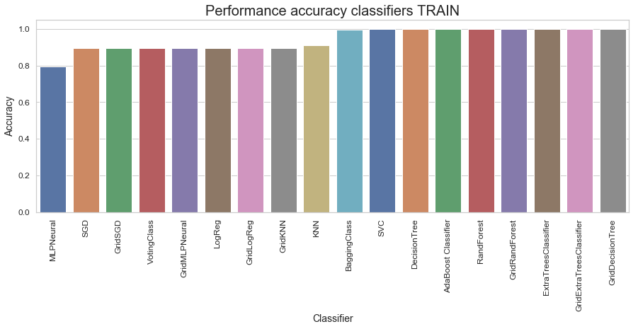

```
Saving figure Performance accuracy classifiers TRAIN
```

```python
a = dataResults[dataResults['Type']=='train']
a.sort_values(by=['Accuracy Average'], inplace=True)
plt.figure(figsize=(15,5))
fig = sns.barplot(x=a['Classifier'], y=a['Accuracy Average'], palette='deep')
plt.xticks(rotation=90)
plt.ylabel('Accuracy')
plt.xlabel('Classifier')
plt.title('Performance accuracy classifiers TRAIN', size=20)
plt.show()
figure = fig.get_figure()
save_figure(figure,"Performance accuracy classifiers TRAIN")
```

Dal grafico è possibile osservare che i classificatori basati su strutture ad albero soffrano di problemi di overfitting.

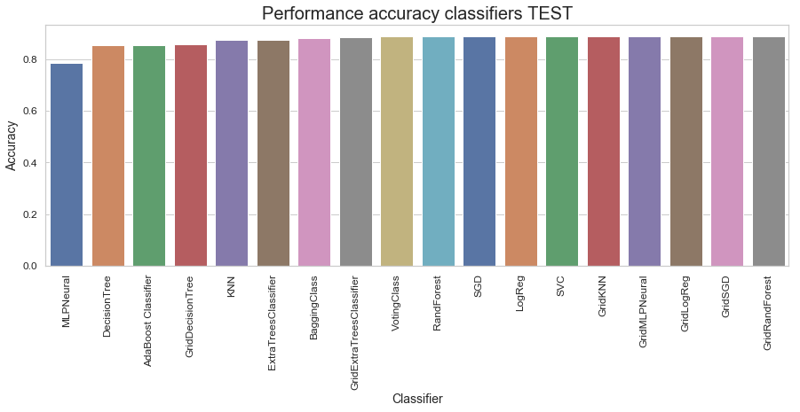

```
Saving figure Performance accuracy classifiers TEST
```

```python
b = dataResults[dataResults['Type']=='test']
b.sort_values(by=['Accuracy Average'], inplace=True)
#print(b.head(40))
plt.figure(figsize=(15,5))
fig = sns.barplot(x=b['Classifier'], y=b['Accuracy Average'], palette='deep')
plt.xticks(rotation=90)
plt.ylabel('Accuracy')
plt.xlabel('Classifier')
plt.title('Performance accuracy classifiers TEST', size=20)
plt.show()
figure = fig.get_figure()
save_figure(figure,"Performance accuracy classifiers TEST")
```

Come si evince dal grafico i migliori classificatari risultano essere: **GridLogReg, GridSGD, GridRandomForest**.

Grid Logistic Regression è un classificatore lineare che, grazie al tuning sui parametri effettuato mediante GridSearch, integra come metodo di ottimizzazione iterativo "newton-cg" ed implementa il paradigma di classificazione multiclasse "One-vs-Rest".

Esaminando il classificatore GridRandomForest si può osservare che l'Ensamble basato sua alberi decisionali risulta migliorare le performance del solo classificatore basato su albero decisionale essendo meno sensibile al problema dell'overfitting.

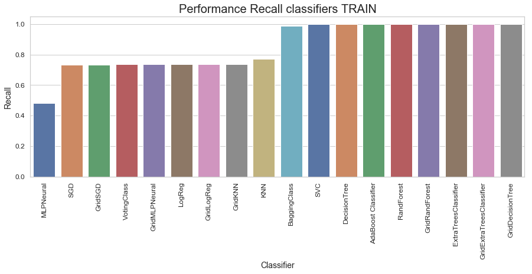

```
Saving figure Performance Recall classifiers TRAIN
```

```python
a.sort_values(by=['Recall Average'], inplace=True)
a.head(40)
#print(hrule(30))
plt.figure(figsize=(15,5))
fig = sns.barplot(x=a['Classifier'], y=a['Recall Average'], palette='deep')
plt.xticks(rotation=90)
plt.ylabel('Recall')
plt.xlabel('Classifier')
plt.title('Performance Recall classifiers TRAIN', size=20)
plt.show()
figure = fig.get_figure()
save_figure(figure,"Performance Recall classifiers TRAIN")
```

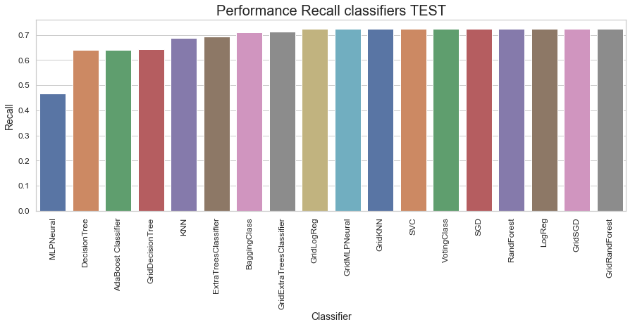

```
Saving figure Performance Recall classifiers TEST
```

```python
b.sort_values(by=['Recall Average'], inplace=True)
#print(a.head(40))
#print(hrule(30))
plt.figure(figsize=(15,5))
fig = sns.barplot(x=b['Classifier'], y=b['Recall Average'], palette='deep')
plt.xticks(rotation=90)
plt.ylabel('Recall')
plt.xlabel('Classifier')
plt.title('Performance Recall classifiers TEST',size=20)
plt.show()
figure = fig.get_figure()
save_figure(figure,"Performance Recall classifiers TEST")
```

Le buone performance di **GridRandomForest** vengono confermate dal volore della recall, questo implica che pochi record della classe "positiva" sono stati erroneamente classificati come "negativi".

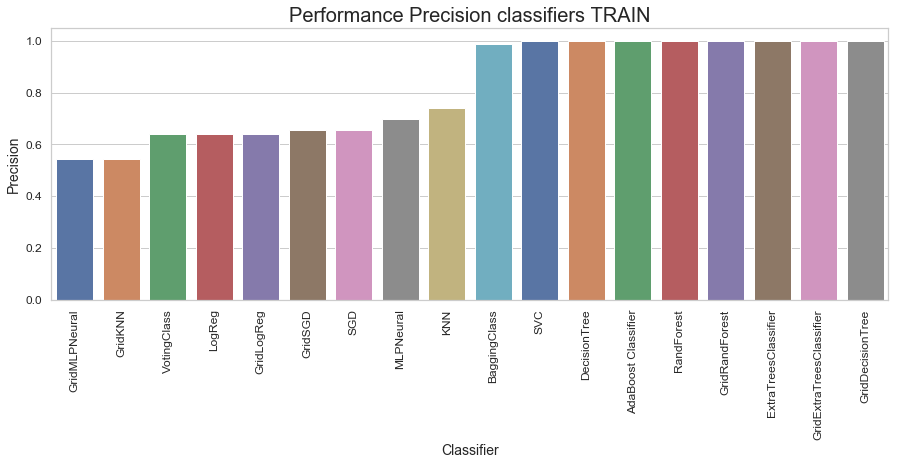

```
Saving figure Performance Precision classifiers TRAIN
```

```python
a.sort_values(by=['Precision Average'], inplace=True)
#print(a.head(40))
#print(hrule(30))
plt.figure(figsize=(15,5))
fig = sns.barplot(x=a['Classifier'], y=a['Precision Average'], palette='deep')
plt.xticks(rotation=90)
plt.ylabel('Precision')
plt.xlabel('Classifier')
plt.title('Performance Precision classifiers TRAIN', size=20)
plt.show()
figure = fig.get_figure()
save_figure(figure,"Performance Precision classifiers TRAIN")
```

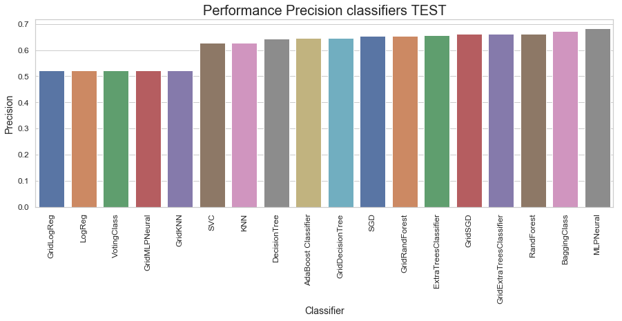

```
Saving figure Performance Precision classifiers TEST
```

```python
b.sort_values(by=['Precision Average'], inplace=True)
#print(a.head(40))
#print(hrule(30))
plt.figure(figsize=(15,5))
fig = sns.barplot(x=b['Classifier'], y=b['Precision Average'], palette='deep')
plt.xticks(rotation=90)
plt.ylabel('Precision')
plt.xlabel('Classifier')
plt.title('Performance Precision classifiers TEST', size=20)
plt.show()
figure = fig.get_figure()
save_figure(figure,"Performance Precision classifiers TEST")
```

Dalla precedente figura si evince come il miglior classificatore risulta essere **MLPNeural** ottenendo una buona percentule sulla precision, grazie alle funzioni non lineare degli hidden layers.

Si conclude che grazie ai classificatori ottenuti è possibile prendire con un alto tasso di successo il Rating di appartenenza per un'applicazione conoscendo la tipologia di dati precedenti.

# APPENDICE

Si affronta un ulteriore studio e analisi su una porzione del dataset che si differenzia per la presenza di dati di valutazione delle applicazioni da parte degli utenti. Quest'ultimi riportano dati di Sentiment Analysis su alcune delle applicazione presenti nel dataset.

Infine si effettuerà un confronto sui migliori risultati dei modelli di classificazione tra il dataset precedentemente utilizzato e il nuovo dataset con l'aggiunta di nuovi attributi di valutazione. Tale confronto ci permetterà di definire se aggiungendo id ati relativi alla Sentiment Analysis ci saranno miglioramenti di sulle prestazioni dei classificatori.

```python
dataset2 =  ps.read_csv("../ProgettoDM/googleplaystore_user_reviews.csv")
dataset2.head(10)
```

|  | App | Translated_Review | Sentiment | Sentiment_Polarity | Sentiment_Subjectivity |
| --- | --- | --- | --- | --- | --- |
| 0 | 10 Best Foods for You | I like eat delicious food. That's I'm cooking ... | Positive | 1.00 | 0.533333 |
| 1 | 10 Best Foods for You | This help eating healthy exercise regular basis | Positive | 0.25 | 0.288462 |
| 2 | 10 Best Foods for You | NaN | NaN | NaN | NaN |
| 3 | 10 Best Foods for You | Works great especially going grocery store | Positive | 0.40 | 0.875000 |
| 4 | 10 Best Foods for You | Best idea us | Positive | 1.00 | 0.300000 |
| 5 | 10 Best Foods for You | Best way | Positive | 1.00 | 0.300000 |
| 6 | 10 Best Foods for You | Amazing | Positive | 0.60 | 0.900000 |
| 7 | 10 Best Foods for You | NaN | NaN | NaN | NaN |
| 8 | 10 Best Foods for You | Looking forward app, | Neutral | 0.00 | 0.000000 |
| 9 | 10 Best Foods for You | It helpful site ! It help foods get ! | Neutral | 0.00 | 0.000000 |

Vengono elimianti i valori nulli presenti nel dataset poichè potrebbero influire negativamente sull'analisi da svolgere

```python
dataset2.dropna(inplace=True)
print(dataset2.info())
print(hrule(30))
```

```
<class 'pandas.core.frame.DataFrame'>
Int64Index: 37427 entries, 0 to 64230
Data columns (total 5 columns):
App                       37427 non-null object
Translated_Review         37427 non-null object
Sentiment                 37427 non-null object
Sentiment_Polarity        37427 non-null float64
Sentiment_Subjectivity    37427 non-null float64
dtypes: float64(2), object(3)
memory usage: 1.7+ MB
None
==============================
```

In seguito vengono esaminate le porzioni di dati in base ai volori dell'attributo Sentiment che comprende tre valori: positivo, negativo o neutrale.

```
Saving figure Review Sentiment
```

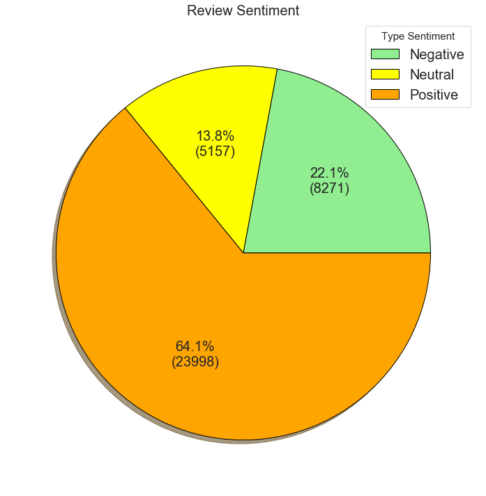

```python
a = dataset2.groupby('Sentiment').count()
plt.figure(figsize=(12,10))

def func(pct, allvals):
    absolute = int(pct/100.*np.sum(allvals))
    return "{:.1f}%\n({:d})".format(pct, absolute)

wedges, texts, autotexts = plt.pie(a.App,shadow=True, autopct=lambda pct: func(pct, a.App), colors=['lightgreen','yellow', 'orange'],wedgeprops = {'linewidth': 1,'edgecolor' :'black'})
legend = plt.legend(wedges, a.index,
          title="Type Sentiment",
          loc="upper right",
          prop={'size': 20})
plt.setp(legend.get_title(), fontsize='15')
plt.setp(autotexts, size=20)
plt.title("Review Sentiment", size=20)
save_fig("Review Sentiment")
```

Si effettua la trasformazione dei valori dell'attributo Sentiment mappandoli con valori interi.

```python
dataset2['Sentiment'] = dataset2['Sentiment'].map({'Positive': 1,'Neutral':0,'Negative':-1 })
print(dataset2[dataset2['Sentiment'] == 1].shape)
print(dataset2[dataset2['Sentiment'] == -1].shape)
print(dataset2[dataset2['Sentiment'] == 0].shape)
print(hrule(20))
print(dataset2.info())
```

```
(23998, 5)
(8271, 5)
(5158, 5)
====================
<class 'pandas.core.frame.DataFrame'>
Int64Index: 37427 entries, 0 to 64230
Data columns (total 5 columns):
App                       37427 non-null object
Translated_Review         37427 non-null object
Sentiment                 37427 non-null int64
Sentiment_Polarity        37427 non-null float64
Sentiment_Subjectivity    37427 non-null float64
dtypes: float64(2), int64(1), object(2)
memory usage: 1.7+ MB
None
```

Viene raffigurata la matrice di correlazione dei dati per esplorare e comprendere meglio le relazioni tra gli attributi.

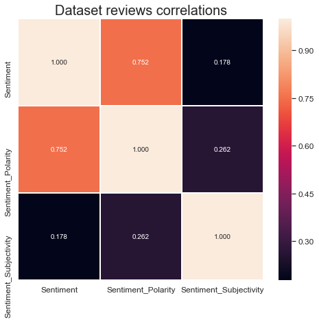

```
Saving figure Dataset reviews correlations
```

```python
fig,ax = plt.subplots(figsize=(8,7))
fig = sns.heatmap(dataset2.corr(), annot=True,linewidths=.5,fmt='.3f')
plt.title("Dataset reviews correlations", size=20)
plt.show()
figure = fig.get_figure()
save_figure(figure,"Dataset reviews correlations")
```

Si è scelto di eliminare le colonne di Translate_Reviews poichè non utile ai fine dell'analisi da condurre.

Viene eliminato l'attributo Sentiment poichè, come si evince dal grafico riportato sopra, è correlata linearmente con Sentiment_Polarity.

```python
dataset2.drop(labels='Translated_Review', axis=1, inplace=True)
dataset2.drop(labels='Sentiment', axis=1, inplace=True)
print(dataset2.describe())
print(hrule(50))
print(dataset2.info())
```

```
       Sentiment_Polarity  Sentiment_Subjectivity
count        37427.000000            37427.000000
mean             0.182171                0.492770
std              0.351318                0.259904
min             -1.000000                0.000000
25%              0.000000                0.357143
50%              0.150000                0.514286
75%              0.400000                0.650000
max              1.000000                1.000000
==================================================
<class 'pandas.core.frame.DataFrame'>
Int64Index: 37427 entries, 0 to 64230
Data columns (total 3 columns):
App                       37427 non-null object
Sentiment_Polarity        37427 non-null float64
Sentiment_Subjectivity    37427 non-null float64
dtypes: float64(2), object(1)
memory usage: 1.1+ MB
None
```

Di seguito si riporta la frequenza della distribuzione dei valori dei due attributi Sentiment_Polarity e Sentiment_Subjectivity.

```
Saving figure Frequency of Sentiment_Polarity and Sentiment_Subjectivity
```

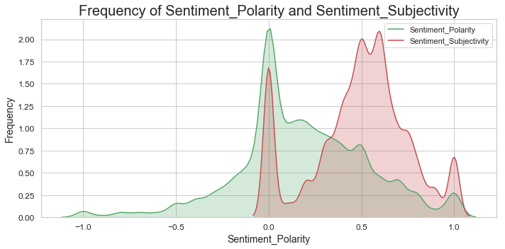

```python
plt.figure(figsize=(10,5))
sns.kdeplot(dataset2.Sentiment_Polarity, color="g", shade = True)
sns.kdeplot(dataset2.Sentiment_Subjectivity, color="r", shade = True)
plt.xlabel("Sentiment_Polarity")
plt.ylabel("Frequency")
plt.title('Frequency of Sentiment_Polarity and Sentiment_Subjectivity',size = 20)
save_fig("Frequency of Sentiment_Polarity and Sentiment_Subjectivity")
```

Si è scelto di eliminare le righe in cui Sentiment_Polarity e Sentiment_Subjectivity valgono zero, ovvero dove la recensione è neutrale poichè influisce negativamente sulla media delle recensioni.

```python
print(dataset2.shape)
print(hrule(30))
dataset2 = dataset2[dataset2['Sentiment_Polarity']!=0.0]
print(dataset2.shape)
print(hrule(30))
print(dataset2.head())
```

```
(37427, 3)
==============================
(32269, 3)
==============================
                     App  Sentiment_Polarity  Sentiment_Subjectivity
0  10 Best Foods for You                1.00                0.533333
1  10 Best Foods for You                0.25                0.288462
3  10 Best Foods for You                0.40                0.875000
4  10 Best Foods for You                1.00                0.300000
5  10 Best Foods for You                1.00                0.300000
```

```
Saving figure Distribution of Sentiment_Polarity and Sentiment_Subjectivity 2
```

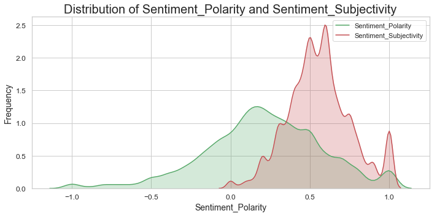

```python
plt.figure(figsize=(10,5))
sns.kdeplot(dataset2.Sentiment_Polarity, color="g", shade = True)
sns.kdeplot(dataset2.Sentiment_Subjectivity, color="r", shade = True)
plt.xlabel("Sentiment_Polarity")
plt.ylabel("Frequency")
plt.title('Distribution of Sentiment_Polarity and Sentiment_Subjectivity',size = 20)
save_fig("Distribution of Sentiment_Polarity and Sentiment_Subjectivity 2")
```

Vengono aggregate tutte le righe per nome di App in modo da ottenere la media dei due attributi di Sentiment

```python
dataset2_ = dataset2.groupby('App').mean()
print(dataset2_.head())
```

```
                                  Sentiment_Polarity  Sentiment_Subjectivity
App
10 Best Foods for You                       0.530943                0.558827
104 找工作 - 找工作 找打工 找兼職 履歷健檢 履歷診療室            0.490506                0.678770
11st                                        0.241726                0.547498
1800 Contacts - Lens Store                  0.363594                0.665337
1LINE – One Line with One Touch             0.213115                0.605085
```

Esaminiamo graficamente i valori e il suo range dell'attributo inserito nel dataset

```
Saving figure Sentiment_Polarity for each APP
```

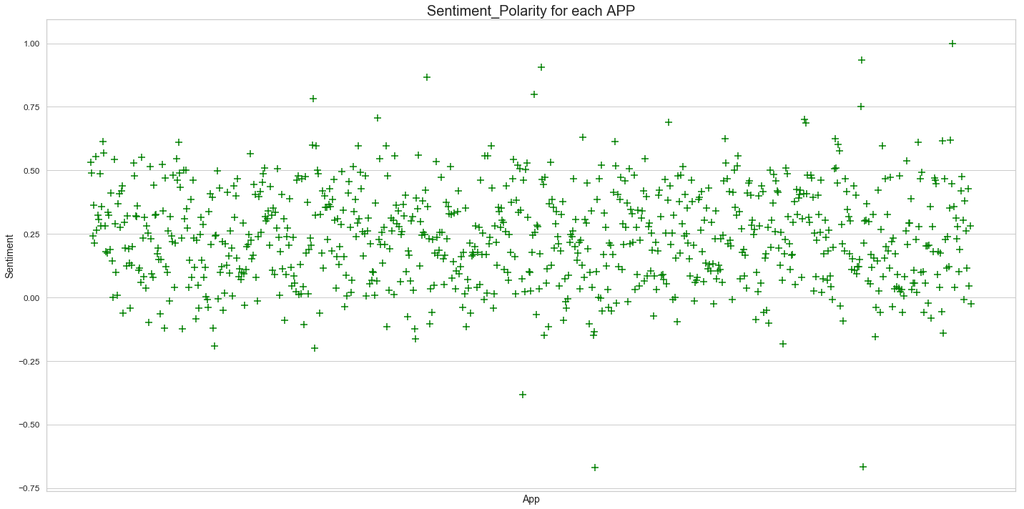

```python
'''
plt.figure(figsize=(20,5))
plt.plot(dataset2_)
plt.xticks([])
plt.xlabel('APP')
plt.ylabel('Sentiment')
plt.title("New feature for Sentiment for each APP",fontsize=20)
save_fig("New feature for Sentiment for each APP")
'''
plt.figure(figsize=(20,10))
plt.scatter(x=dataset2_.index,y=dataset2_["Sentiment_Polarity"],color="green",marker='+',s=100)
plt.xlabel("App")
plt.xticks([])
plt.ylabel("Sentiment")
plt.title("Sentiment_Polarity for each APP",fontsize=20)
save_fig("Sentiment_Polarity for each APP")
```

```
Saving figure Sentiment_Subjectivity for each APP
```

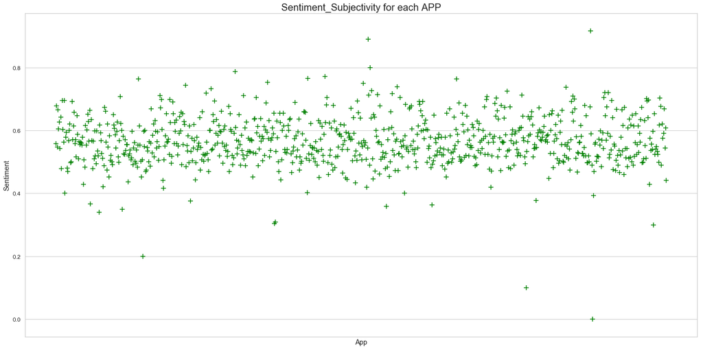

```python
plt.figure(figsize=(20,10))
plt.scatter(x=dataset2_.index,y=dataset2_["Sentiment_Subjectivity"],color="green",marker='+',s=100)
plt.xlabel("App")
plt.xticks([])
plt.ylabel("Sentiment")
plt.title("Sentiment_Subjectivity for each APP",fontsize=20)
save_fig("Sentiment_Subjectivity for each APP")
```

Aggregriamo la nuova misura creata nel primo dataset utilizzato

```python
dataset = dataset1Appendice.merge(dataset2_, how='inner', on='App')
print(dataset.info())
```

```
<class 'pandas.core.frame.DataFrame'>
Int64Index: 814 entries, 0 to 813
Data columns (total 49 columns):
App                       814 non-null object
Rating                    814 non-null int32
Reviews                   814 non-null int64
Size                      814 non-null int32
Installs                  814 non-null int32
Type                      814 non-null int64
Price                     814 non-null float64
Last Updated              814 non-null float64
ART_AND_DESIGN            814 non-null uint8
AUTO_AND_VEHICLES         814 non-null uint8
BEAUTY                    814 non-null uint8
BOOKS_AND_REFERENCE       814 non-null uint8
BUSINESS                  814 non-null uint8
COMICS                    814 non-null uint8
COMMUNICATION             814 non-null uint8
DATING                    814 non-null uint8
EDUCATION                 814 non-null uint8
ENTERTAINMENT             814 non-null uint8
EVENTS                    814 non-null uint8
FAMILY                    814 non-null uint8
FINANCE                   814 non-null uint8
FOOD_AND_DRINK            814 non-null uint8
GAME                      814 non-null uint8
HEALTH_AND_FITNESS        814 non-null uint8
HOUSE_AND_HOME            814 non-null uint8
LIBRARIES_AND_DEMO        814 non-null uint8
LIFESTYLE                 814 non-null uint8
MAPS_AND_NAVIGATION       814 non-null uint8
MEDICAL                   814 non-null uint8
NEWS_AND_MAGAZINES        814 non-null uint8
PARENTING                 814 non-null uint8
PERSONALIZATION           814 non-null uint8
PHOTOGRAPHY               814 non-null uint8
PRODUCTIVITY              814 non-null uint8
SHOPPING                  814 non-null uint8
SOCIAL                    814 non-null uint8
SPORTS                    814 non-null uint8
TOOLS                     814 non-null uint8
TRAVEL_AND_LOCAL          814 non-null uint8
VIDEO_PLAYERS             814 non-null uint8
WEATHER                   814 non-null uint8
Adults only 18+           814 non-null uint8
Everyone                  814 non-null uint8
Everyone 10+              814 non-null uint8
Mature 17+                814 non-null uint8
Teen                      814 non-null uint8
Unrated                   814 non-null uint8
Sentiment_Polarity        814 non-null float64
Sentiment_Subjectivity    814 non-null float64
dtypes: float64(4), int32(3), int64(2), object(1), uint8(39)
memory usage: 91.4+ KB
None
```

```python
dataset.drop(labels='App', axis=1, inplace=True )
```

```python
#print(dataset1.head())
#print(hrule(40))
Y = dataset['Rating']
X = dataset.drop('Rating', axis=1)
from sklearn.model_selection import train_test_split
X_train, X_test, y_train, y_test = train_test_split(X,Y, test_size=0.3, random_state=42)
print(X_train.shape, y_train.shape, X_test.shape, y_test.shape)
print(hrule(40))
#print(X_train.info(), y_train.describe())
```

```
(569, 47) (569,) (245, 47) (245,)
========================================
```

```python
dataset.dropna(inplace=True)
```

## Appendice: Allenamento dei Classificatori

Per effettuare l'analisi anche su questo Dataset utilizziamo i 3 migliori classificatori precedentemente utilizzati.

```python
#dataResultsApp = ps.DataFrame(columns=['Classifier', 'Accuracy Average App', 'Recall Average App','Precision Average App', 'Type'] )
#dataResultsApp.to_csv("../progettoDM/resultAppendice.csv",index=False)

def carica(name, accuracy,recall, precision, tipo):

    dataResultsApp = ps.read_csv("../progettoDM/resultAppendice.csv")
    dict = {
      "Classifier": name,
      "Accuracy Average App": accuracy,
      "Recall Average App": recall,
      'Precision Average App': precision,
      'Type':tipo
      }
    dataResultsApp=dataResultsApp.append(dict, ignore_index=True)
    #print(dict_)
    #dataResults = ps.concat([dict_, dataResults]).reset_index(drop = True)
    #dataResults = dataResults.append(dict,ignore_index=True)
    dataResultsApp.to_csv("../progettoDM/resultAppendice.csv",index=False)
    #print(dataResults.head())
    return dataResultsApp
```

**Grid SGD CLASSIFIER**

```python
from sklearn.linear_model import *
from sklearn.model_selection import *

'''param_sgd_grid = {
    'loss': ['hinge', 'log', 'modified_huber', 'squared_hinge', 'perceptron'],
    'penalty': ['l2','elasticnet', 'l1'],
}
grid_search = GridSearchCV(SGDClassifier(max_iter=1000, tol=-np.infty, random_state=42), param_sgd_grid, cv=10,scoring='accuracy', return_train_score=True)
grid_search.fit(X_train, y_train)
print("Best Param:", grid_search.best_params_)
best_sgd_clf_appendice = grid_search.best_estimator_

# save the model to disk
filename = './Model/best_sgd_clf_appendice.sav'
pickle.dump(best_sgd_clf_appendice, open(filename, 'wb'))'''

# load the model from disk
filename = './Model/best_sgd_clf_appendice.sav'
best_sgd_clf_appendice = pickle.load(open(filename, 'rb'))
print(best_sgd_clf_appendice)
```

```
SGDClassifier(alpha=0.0001, average=False, class_weight=None,
       early_stopping=False, epsilon=0.1, eta0=0.0, fit_intercept=True,
       l1_ratio=0.15, learning_rate='optimal', loss='squared_hinge',
       max_iter=1000, n_iter=None, n_iter_no_change=5, n_jobs=None,
       penalty='l1', power_t=0.5, random_state=42, shuffle=True, tol=-inf,
       validation_fraction=0.1, verbose=0, warm_start=False)
```

Verifica delle prestazioni sul TrainSet:

```python
y_pred_sgd= best_sgd_clf_appendice.predict(X_train)
accuracy, recall, precision = compute_Average(y_pred_sgd,y_train)
name = 'GridSGD'
#dataResultsApp = carica( name, accuracy,recall, precision, 'train')
```

```
The Accuracy Average is: 0.9479789103690685

The Recall Average is: 0.8699472759226714

The Precision Average is: 0.8221938186788801
```

Verifica delle prestazioni sul Test Set:

```python
y_pred_sgd= best_sgd_clf_appendice.predict(X_test)
accuracy, recall, precision = compute_Average(y_pred_sgd,y_test)
#dataResultsApp = carica( name, accuracy,recall, precision, 'test')
```

```
The Accuracy Average is: 0.9640816326530611

The Recall Average is: 0.9102040816326531

The Precision Average is: 0.9184698147041243
```

**Grid Logistic Regression**

```python
from sklearn.linear_model import LogisticRegression
'''logreg_clf = LogisticRegression(solver='lbfgs',multi_class='ovr')
param_logreg_grid = [ {'penalty': ['l2'], 'solver': ['newton-cg', 'sag','lbfgs']},]
grid_search = GridSearchCV(logreg_clf, param_logreg_grid, cv=10,
                           scoring='accuracy', return_train_score=True)
grid_search.fit(X_train, y_train)
print("Best Param:", grid_search.best_params_)
best_logreg_clf_appendice = grid_search.best_estimator_

# save the model to disk
filename = './Model/best_logreg_clf_appendice.sav'
pickle.dump(best_logreg_clf_appendice, open(filename, 'wb'))'''

# load the model from disk
filename = './Model/best_logreg_clf_appendice.sav'
best_logreg_clf_appendice = pickle.load(open(filename, 'rb'))
print(best_logreg_clf_appendice)
```

```
LogisticRegression(C=1.0, class_weight=None, dual=False, fit_intercept=True,
          intercept_scaling=1, max_iter=100, multi_class='ovr',
          n_jobs=None, penalty='l2', random_state=None, solver='newton-cg',
          tol=0.0001, verbose=0, warm_start=False)
```

Verifica delle prestazioni sul TrainSet:

```python
y_pred_logreg= best_logreg_clf_appendice.predict(X_train)
accuracy, recall, precision = compute_Average(y_pred_logreg,y_train)
name = 'GridLogReg'
#dataResultsApp = carica( name, accuracy,recall, precision, 'train')
```

```
The Accuracy Average is: 0.9493848857644991

The Recall Average is: 0.8734622144112478

The Precision Average is: 0.8859872769127948
```

Verifica delle prestazioni sul Test Set

```python
y_pred_logreg= best_logreg_clf_appendice.predict(X_test)
accuracy, recall, precision = compute_Average(y_pred_logreg,y_test)
#dataResultsApp = carica( name, accuracy,recall, precision, 'test')
```

```
The Accuracy Average is: 0.9542857142857143

The Recall Average is: 0.8857142857142857

The Precision Average is: 0.7844897959183673
```

**Grid Random Forest Classifier**

```python
from sklearn.ensemble import RandomForestClassifier
'''
rnd_clf = RandomForestClassifier(n_estimators=100, random_state=42)
param_rnd_grid = {
    'n_estimators': [10,50,100,200],
    'criterion': ['gini','entropy'],
}
grid_search = GridSearchCV(rnd_clf, param_rnd_grid, cv=10,scoring='accuracy', return_train_score=True)
grid_search.fit(X_train, y_train)
print("Best Param:", grid_search.best_params_)
best_rnd_clf_appendice = grid_search.best_estimator_

# save the model to disk
filename = './Model/best_rnd_clf_appendice.sav'
pickle.dump(best_rnd_clf_appendice, open(filename, 'wb'))'''

# load the model from disk
filename = './Model/best_rnd_clf_appendice.sav'

best_rnd_clf_appendice = pickle.load(open(filename, 'rb'))
print(best_rnd_clf_appendice)
```

```
RandomForestClassifier(bootstrap=True, class_weight=None, criterion='entropy',
            max_depth=None, max_features='auto', max_leaf_nodes=None,
            min_impurity_decrease=0.0, min_impurity_split=None,
            min_samples_leaf=1, min_samples_split=2,
            min_weight_fraction_leaf=0.0, n_estimators=50, n_jobs=None,
            oob_score=False, random_state=42, verbose=0, warm_start=False)
```

Verifica delle prestazioni sul Train Set dopo La ricerca dopo la ricerca dei parametri

```python
y_pred_rnd= best_rnd_clf_appendice.predict(X_train)
accuracy, recall, precision = compute_Average(y_pred_rnd,y_train)
name = 'GridRandForest'
#dataResultsApp = carica( name, accuracy,recall, precision, 'train')
```

```
The Accuracy Average is: 1.0

The Recall Average is: 1.0

The Precision Average is: 1.0
```

Verifica delle prestazioni sul Test Set dopo la ricerca dei parametri

```python
y_pred_rnd= best_rnd_clf_appendice.predict(X_test)
accuracy, recall, precision = compute_Average(y_pred_rnd,y_test)
#dataResultsApp = carica( name, accuracy,recall, precision, 'test')
```

```
The Accuracy Average is: 0.9526530612244898

The Recall Average is: 0.8816326530612245

The Precision Average is: 0.8354761904761905
```

## Valutazione dei risultati ottenuti

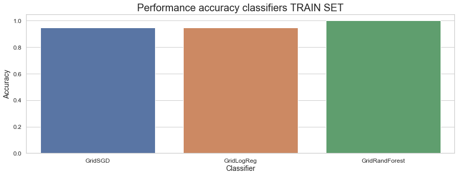

```
Saving figure Performance Accuracy classifiers TRAIN SET appendice
```

```python
dataResultsApp = ps.read_csv("../ProgettoDM/resultAppendice.csv")

a = dataResultsApp[dataResultsApp['Type']=='train']
a.sort_values(by=['Accuracy Average App'], inplace=True)
#print(a.head(40))
#print(hrule(30))
plt.figure(figsize=(15,5))
fig = sns.barplot(x=a['Classifier'], y=a['Accuracy Average App'], palette='deep')
plt.xticks(rotation=0)
plt.ylabel('Accuracy')
plt.xlabel('Classifier')
plt.title('Performance accuracy classifiers TRAIN SET', size=20)
plt.show()
figure = fig.get_figure()
save_figure(figure,"Performance Accuracy classifiers TRAIN SET appendice")
```

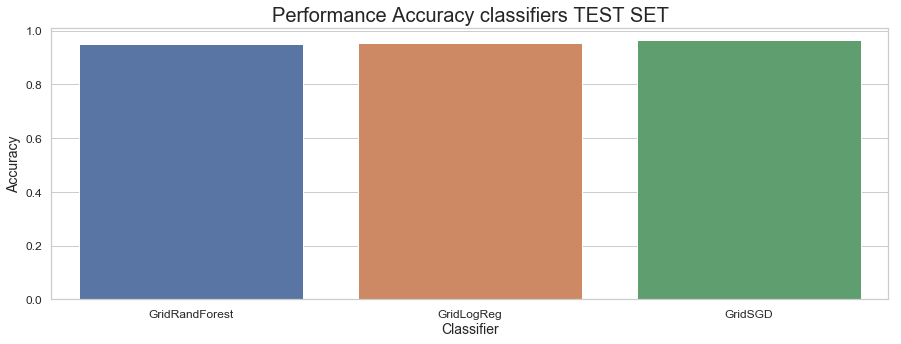

```
Saving figure Performance Accuracy classifiers TEST SET appendice
```

```python
b = dataResultsApp[dataResultsApp['Type']=='test']
b.sort_values(by=['Accuracy Average App'], inplace=True)
#print(a.head(40))
#print(hrule(30))
plt.figure(figsize=(15,5))
fig = sns.barplot(x=b['Classifier'], y=b['Accuracy Average App'])
plt.xticks(rotation=0)
plt.ylabel('Accuracy')
plt.xlabel('Classifier')
plt.title('Performance Accuracy classifiers TEST SET', size=20)
plt.show()
figure = fig.get_figure()
save_figure(figure,"Performance Accuracy classifiers TEST SET appendice")
```

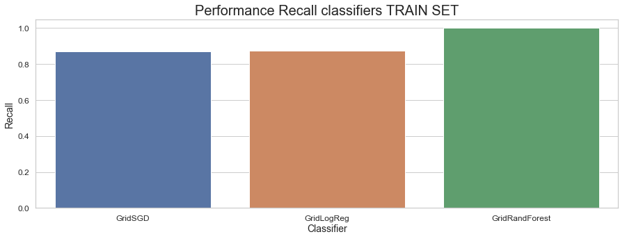

```
Saving figure Performance Recall classifiers TRAIN SET appendice
```

```python
a.sort_values(by=['Recall Average App'], inplace=True)
#print(a.head(40))
#print(hrule(30))
plt.figure(figsize=(15,5))
fig = sns.barplot(x=a['Classifier'], y=a['Recall Average App'], palette='deep')
plt.xticks(rotation=0)
plt.ylabel('Recall')
plt.xlabel('Classifier')
plt.title('Performance Recall classifiers TRAIN SET',size=20)
plt.show()
figure = fig.get_figure()
save_figure(figure,"Performance Recall classifiers TRAIN SET appendice")
```

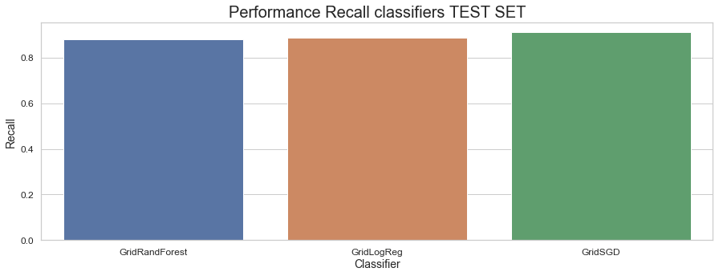

```
Saving figure Performance Recall classifiers TEST SET appendice
```

```python
b.sort_values(by=['Recall Average App'], inplace=True)
#print(a.head(40))
#print(hrule(30))
plt.figure(figsize=(15,5))
fig = sns.barplot(x=b['Classifier'], y=b['Recall Average App'], palette='deep')
plt.xticks(rotation=0)
plt.ylabel('Recall')
plt.xlabel('Classifier')
plt.title('Performance Recall classifiers TEST SET', size=20)
plt.show()
figure = fig.get_figure()
save_figure(figure,"Performance Recall classifiers TEST SET appendice")
```

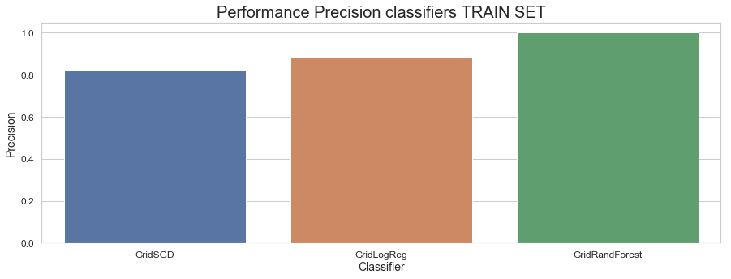

```
Saving figure Performance Precision classifiers TRAIN SET appendice
```

```python
a.sort_values(by=['Precision Average App'], inplace=True)
#print(a.head(40))
#print(hrule(30))
plt.figure(figsize=(15,5))
fig = sns.barplot(x=a['Classifier'], y=a['Precision Average App'], palette='deep')
plt.xticks(rotation=0)
plt.ylabel('Precision')
plt.xlabel('Classifier')
plt.title('Performance Precision classifiers TRAIN SET',size=20)
plt.show()
figure = fig.get_figure()
save_figure(figure,"Performance Precision classifiers TRAIN SET appendice")
```

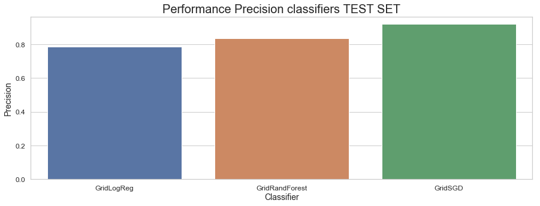

```
Saving figure Performance Precision classifiers TEST SET appendice
```

```python
b.sort_values(by=['Precision Average App'], inplace=True)
#print(a.head(40))
#print(hrule(30))
plt.figure(figsize=(15,5))
fig = sns.barplot(x=b['Classifier'], y=b['Precision Average App'], palette='deep')
plt.xticks(rotation=0)
plt.ylabel('Precision')
plt.xlabel('Classifier')
plt.title('Performance Precision classifiers TEST SET',size=20)
plt.show()
figure = fig.get_figure()
save_figure(figure,"Performance Precision classifiers TEST SET appendice")
```

## Confronto risultati classificatori appendice e classificatori

```python
dataResults = ps.read_csv("../progettoDM/result.csv")
datasetFinale = dataResultsApp.merge(dataResults, how='inner', on=['Classifier','Type'])

datasetFinale.head(20)
```

|  | Classifier | Accuracy Average App | Recall Average App | Precision Average App | Type | Accuracy Average | Recall Average | Precision Average |
| --- | --- | --- | --- | --- | --- | --- | --- | --- |
| 0 | GridSGD | 0.947979 | 0.869947 | 0.822194 | train | 0.893167 | 0.732916 | 0.654680 |
| 1 | GridSGD | 0.964082 | 0.910204 | 0.918470 | test | 0.889756 | 0.724390 | 0.661695 |
| 2 | GridLogReg | 0.949385 | 0.873462 | 0.885987 | train | 0.894631 | 0.736577 | 0.640883 |
| 3 | GridLogReg | 0.954286 | 0.885714 | 0.784490 | test | 0.889268 | 0.723171 | 0.522976 |
| 4 | GridRandForest | 1.000000 | 1.000000 | 1.000000 | train | 1.000000 | 1.000000 | 1.000000 |
| 5 | GridRandForest | 0.952653 | 0.881633 | 0.835476 | test | 0.890000 | 0.725000 | 0.654768 |

```
Saving figure Confronto classificatori train
```

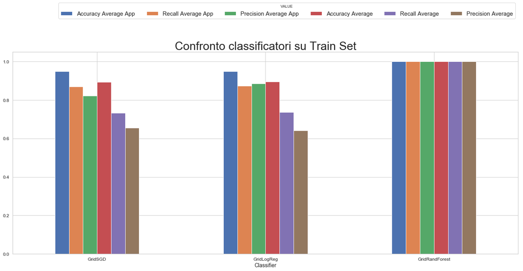

```python
a = datasetFinale[datasetFinale['Type']=='train']
plt.figure(figsize=(100,100))
ax = a.plot.bar(x='Classifier')
plt.gcf().set_size_inches(20,10)
plt.legend(title="VALUE",loc="lower right",bbox_to_anchor=(0., 1.15, 1., .102),  ncol=6,  prop={'size': 15})
plt.xlabel('Classifier')
plt.xticks(rotation=0)

plt.title("Confronto classificatori su Train Set", size=30)
save_fig("Confronto classificatori train")
```

```
Saving figure Confronto classificatori test
```

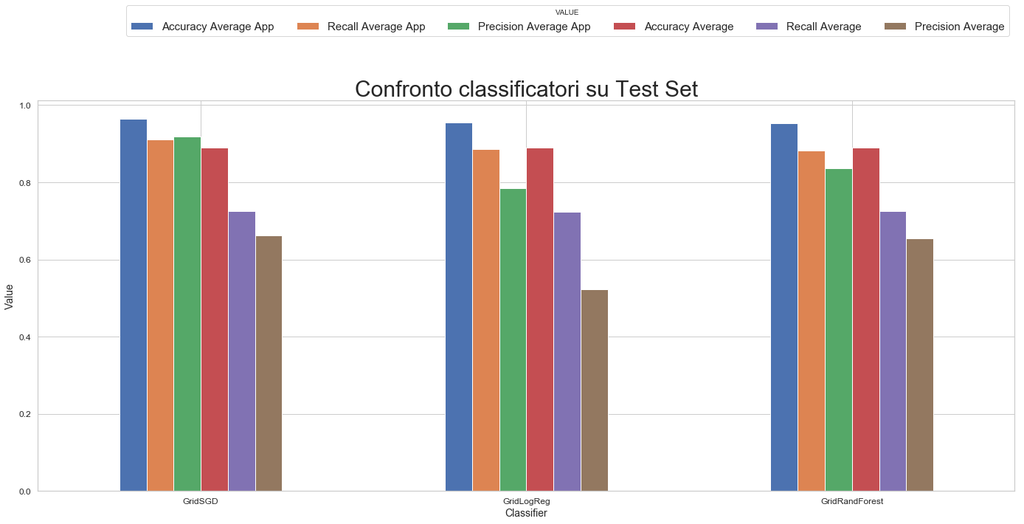

```python
b = datasetFinale[datasetFinale['Type']=='test']
plt.figure(figsize=(30,30))
ax = b.plot.bar(x='Classifier')

plt.legend(title="VALUE",loc="lower right",bbox_to_anchor=(0., 1.15, 1., .102),  ncol=6,  prop={'size': 15})
plt.gcf().set_size_inches(20,10)

plt.xlabel('Classifier')
plt.ylabel('Value')
plt.xticks(rotation=0)
plt.title("Confronto classificatori su Test Set", size=30)
save_fig("Confronto classificatori test")
```

```
Saving figure Confronto classificatori Accuracy su TestSet
```

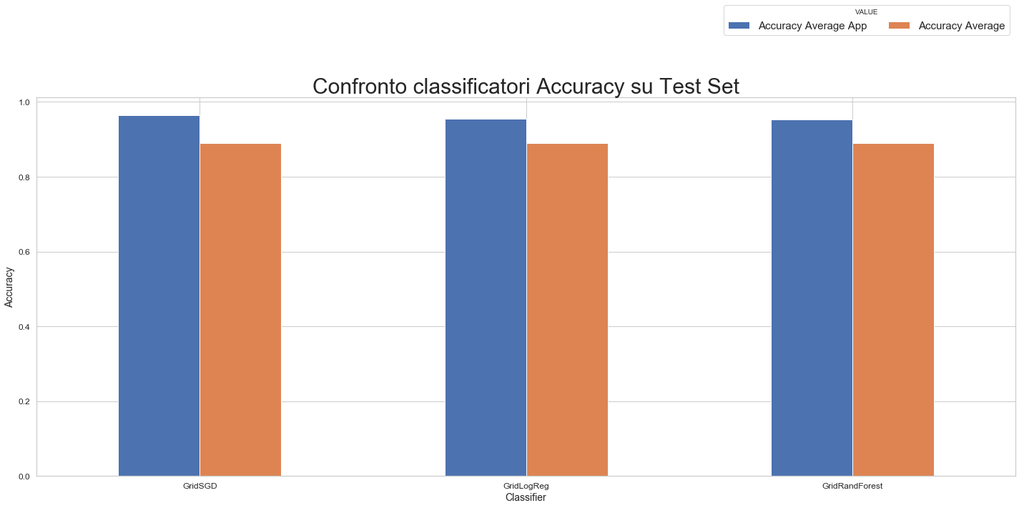

```python
accuracy = datasetFinale.drop([ 'Recall Average App','Precision Average App','Recall Average','Precision Average'], axis=1)
b = accuracy[accuracy['Type'] == 'test']
plt.figure(figsize=(30,30))
ax = b.plot.bar(x='Classifier')
plt.legend(title="VALUE",loc="lower right",bbox_to_anchor=(0., 1.15, 1., .102),  ncol=6,  prop={'size': 15})
plt.gcf().set_size_inches(20,10)

plt.xlabel('Classifier')
plt.ylabel('Accuracy')
plt.xticks(rotation=0)
plt.title("Confronto classificatori Accuracy su Test Set", size=30)
save_fig("Confronto classificatori Accuracy su TestSet")
```

```
Saving figure Confronto classificatori Recall su TestSet
```

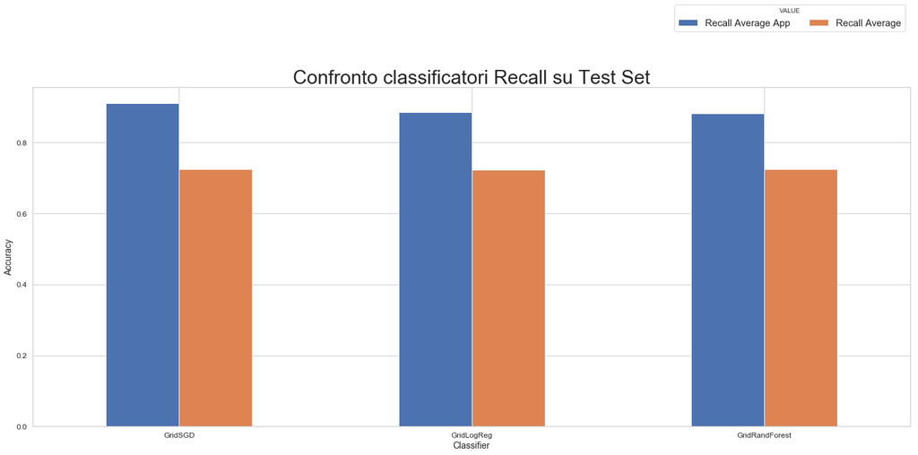

```python
recall = datasetFinale.drop([ 'Accuracy Average App','Precision Average App','Accuracy Average','Precision Average'], axis=1)
b = recall[recall['Type'] == 'test']
plt.figure(figsize=(30,30))
ax = b.plot.bar(x='Classifier')

plt.legend(title="VALUE",loc="lower right",bbox_to_anchor=(0., 1.15, 1., .102),  ncol=6,  prop={'size': 15})
plt.gcf().set_size_inches(20,10)

plt.xlabel('Classifier')
plt.ylabel('Accuracy')
plt.xticks(rotation=0)
plt.title("Confronto classificatori Recall su Test Set", size=30)
save_fig("Confronto classificatori Recall su TestSet")
```

Considerando i valori della recall si può notare come l'aggiunta di dati di Sentiment Analysis incrementa le performance.

```
Saving figure Confronto classificatori Precision su TestSet
```

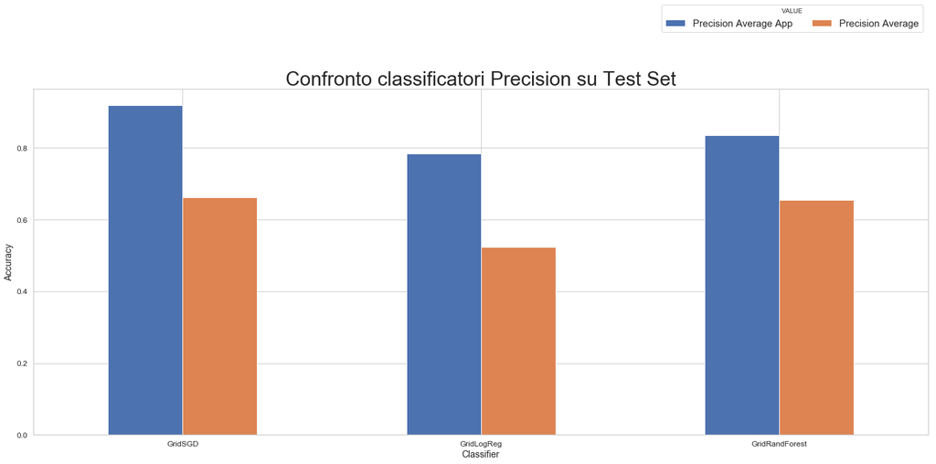

```python
precision = datasetFinale.drop([ 'Recall Average App','Accuracy Average App','Recall Average','Accuracy Average'], axis=1)
b = precision[precision['Type'] == 'test']
plt.figure(figsize=(30,30))
ax = b.plot.bar(x='Classifier')

plt.legend(title="VALUE",loc="lower right",bbox_to_anchor=(0., 1.15, 1., .102),  ncol=6,  prop={'size': 15})
plt.gcf().set_size_inches(20,10)

plt.xlabel('Classifier')
plt.ylabel('Accuracy')
plt.xticks(rotation=0)
plt.title("Confronto classificatori Precision su Test Set", size=30)
save_fig("Confronto classificatori Precision su TestSet")
```

```python
datasetFinale.head(10)
```

|  | Classifier | Accuracy Average App | Recall Average App | Precision Average App | Type | Accuracy Average | Recall Average | Precision Average |
| --- | --- | --- | --- | --- | --- | --- | --- | --- |
| 0 | GridSGD | 0.947979 | 0.869947 | 0.822194 | train | 0.893167 | 0.732916 | 0.654680 |
| 1 | GridSGD | 0.964082 | 0.910204 | 0.918470 | test | 0.889756 | 0.724390 | 0.661695 |
| 2 | GridLogReg | 0.949385 | 0.873462 | 0.885987 | train | 0.894631 | 0.736577 | 0.640883 |
| 3 | GridLogReg | 0.954286 | 0.885714 | 0.784490 | test | 0.889268 | 0.723171 | 0.522976 |
| 4 | GridRandForest | 1.000000 | 1.000000 | 1.000000 | train | 1.000000 | 1.000000 | 1.000000 |
| 5 | GridRandForest | 0.952653 | 0.881633 | 0.835476 | test | 0.890000 | 0.725000 | 0.654768 |